# lab4_final_CS7324

### Lab Assignment Four: Multi-Layer Perceptron

Team Members :

1. Hessam Emami
2. Jinyu Du

**Dataset:** US Census Demographic Data

**URL:** https://www.kaggle.com/muonneutrino/us-census-demographic-data/data

In this lab, we aim to classify child poverty in each county. The child poverty in the dataset is a numerical attribute. It is converted to four categories based on quartiles because we want to create a classification model for predicting child poverty. Multi-layer perceptrons will be implemented, and their performance will be evaluated.

```python
import copy
import matplotlib.pyplot as plt
import missingno as mn
import numpy as np
import pandas as pd
# import matplotlib
import warnings

warnings.simplefilter('ignore', DeprecationWarning)
%matplotlib inline
```

```python
dataset_url = 'ds/acs2017_census_tract_data.csv'
df = pd.read_csv(dataset_url)
df.head()
```

|  | TractId | State | County | TotalPop | Men | Women | Hispanic | White | Black | Native | ... | Walk | OtherTransp | WorkAtHome | MeanCommute | Employed | PrivateWork | PublicWork | SelfEmployed | FamilyWork | Unemployment |
| --- | --- | --- | --- | --- | --- | --- | --- | --- | --- | --- | --- | --- | --- | --- | --- | --- | --- | --- | --- | --- | --- |
| 0 | 1001020100 | Alabama | Autauga County | 1845 | 899 | 946 | 2.4 | 86.3 | 5.2 | 0.0 | ... | 0.5 | 0.0 | 2.1 | 24.5 | 881 | 74.2 | 21.2 | 4.5 | 0.0 | 4.6 |
| 1 | 1001020200 | Alabama | Autauga County | 2172 | 1167 | 1005 | 1.1 | 41.6 | 54.5 | 0.0 | ... | 0.0 | 0.5 | 0.0 | 22.2 | 852 | 75.9 | 15.0 | 9.0 | 0.0 | 3.4 |
| 2 | 1001020300 | Alabama | Autauga County | 3385 | 1533 | 1852 | 8.0 | 61.4 | 26.5 | 0.6 | ... | 1.0 | 0.8 | 1.5 | 23.1 | 1482 | 73.3 | 21.1 | 4.8 | 0.7 | 4.7 |
| 3 | 1001020400 | Alabama | Autauga County | 4267 | 2001 | 2266 | 9.6 | 80.3 | 7.1 | 0.5 | ... | 1.5 | 2.9 | 2.1 | 25.9 | 1849 | 75.8 | 19.7 | 4.5 | 0.0 | 6.1 |
| 4 | 1001020500 | Alabama | Autauga County | 9965 | 5054 | 4911 | 0.9 | 77.5 | 16.4 | 0.0 | ... | 0.8 | 0.3 | 0.7 | 21.0 | 4787 | 71.4 | 24.1 | 4.5 | 0.0 | 2.3 |

5 rows × 37 columns

```python
print(df.info())
```

```
<class 'pandas.core.frame.DataFrame'>
RangeIndex: 74001 entries, 0 to 74000
Data columns (total 37 columns):
 #   Column            Non-Null Count  Dtype
---  ------            --------------  -----
 0   TractId           74001 non-null  int64
 1   State             74001 non-null  object
 2   County            74001 non-null  object
 3   TotalPop          74001 non-null  int64
 4   Men               74001 non-null  int64
 5   Women             74001 non-null  int64
 6   Hispanic          73305 non-null  float64
 7   White             73305 non-null  float64
 8   Black             73305 non-null  float64
 9   Native            73305 non-null  float64
```

[output cut: 30 more lines]

```python
df.shape
```

```
(74001, 37)
```

```python
total_missing_values = df.isnull().sum().sort_values(ascending = False)
total_missing_values
```

```
Income              1116
IncomeErr           1116
ChildPoverty        1110
MeanCommute          946
Poverty              842
Construction         811
SelfEmployed         811
PublicWork           811
PrivateWork          811
FamilyWork           811
Professional         811
Service              811
Office               811
Production           811
Unemployment         810
Drive                801
Transit              801
Walk                 801
OtherTransp          801
WorkAtHome           801
Carpool              801
IncomePerCapErr      745
IncomePerCap         745
Native               696
Hispanic             696
White                696
Black                696
Asian                696
Pacific              696
VotingAgeCitizen       0
Employed               0
Women                  0
Men                    0
TotalPop               0
County                 0
State                  0
TractId                0
dtype: int64
```

```python
df_imputed = copy.deepcopy(df)
del df_imputed['TractId']
df_imputed = df_imputed.dropna()
```

```python
total_missing_values = df_imputed.isnull().sum().sort_values(ascending = False)
total_missing_values
```

```
Unemployment        0
FamilyWork          0
IncomePerCapErr     0
IncomePerCap        0
IncomeErr           0
Income              0
VotingAgeCitizen    0
Pacific             0
Asian               0
Native              0
Black               0
White               0
Hispanic            0
Women               0
Men                 0
TotalPop            0
County              0
Poverty             0
ChildPoverty        0
Professional        0
OtherTransp         0
SelfEmployed        0
PublicWork          0
PrivateWork         0
Employed            0
MeanCommute         0
WorkAtHome          0
Walk                0
Service             0
Transit             0
Carpool             0
Drive               0
Production          0
Construction        0
Office              0
State               0
dtype: int64
```

```python
print(df_imputed.info())
```

```
<class 'pandas.core.frame.DataFrame'>
Int64Index: 72718 entries, 0 to 74000
Data columns (total 36 columns):
 #   Column            Non-Null Count  Dtype
---  ------            --------------  -----
 0   State             72718 non-null  object
 1   County            72718 non-null  object
 2   TotalPop          72718 non-null  int64
 3   Men               72718 non-null  int64
 4   Women             72718 non-null  int64
 5   Hispanic          72718 non-null  float64
 6   White             72718 non-null  float64
 7   Black             72718 non-null  float64
 8   Native            72718 non-null  float64
 9   Asian             72718 non-null  float64
```

[output cut: 29 more lines]

### Convert categorical data to integer

```python
from sklearn import preprocessing
le = preprocessing.LabelEncoder()

df_imputed['State'] = le.fit_transform(df_imputed['State'])
df_imputed['County'] = le.fit_transform(df_imputed['County'])
df_imputed.head()
```

|  | State | County | TotalPop | Men | Women | Hispanic | White | Black | Native | Asian | ... | Walk | OtherTransp | WorkAtHome | MeanCommute | Employed | PrivateWork | PublicWork | SelfEmployed | FamilyWork | Unemployment |
| --- | --- | --- | --- | --- | --- | --- | --- | --- | --- | --- | --- | --- | --- | --- | --- | --- | --- | --- | --- | --- | --- |
| 0 | 0 | 89 | 1845 | 899 | 946 | 2.4 | 86.3 | 5.2 | 0.0 | 1.2 | ... | 0.5 | 0.0 | 2.1 | 24.5 | 881 | 74.2 | 21.2 | 4.5 | 0.0 | 4.6 |
| 1 | 0 | 89 | 2172 | 1167 | 1005 | 1.1 | 41.6 | 54.5 | 0.0 | 1.0 | ... | 0.0 | 0.5 | 0.0 | 22.2 | 852 | 75.9 | 15.0 | 9.0 | 0.0 | 3.4 |
| 2 | 0 | 89 | 3385 | 1533 | 1852 | 8.0 | 61.4 | 26.5 | 0.6 | 0.7 | ... | 1.0 | 0.8 | 1.5 | 23.1 | 1482 | 73.3 | 21.1 | 4.8 | 0.7 | 4.7 |
| 3 | 0 | 89 | 4267 | 2001 | 2266 | 9.6 | 80.3 | 7.1 | 0.5 | 0.2 | ... | 1.5 | 2.9 | 2.1 | 25.9 | 1849 | 75.8 | 19.7 | 4.5 | 0.0 | 6.1 |
| 4 | 0 | 89 | 9965 | 5054 | 4911 | 0.9 | 77.5 | 16.4 | 0.0 | 3.1 | ... | 0.8 | 0.3 | 0.7 | 21.0 | 4787 | 71.4 | 24.1 | 4.5 | 0.0 | 2.3 |

5 rows × 36 columns

### Change the 'ChildPoverty' attribute to a categorical attribute

```python
df_tmp = copy.deepcopy(df_imputed)
df_tmp.sort_values(by=['ChildPoverty'], inplace=True)
df_tmp = df_tmp.reset_index(drop=True)

median_index  = df_tmp[df_tmp['ChildPoverty'] == df_tmp['ChildPoverty'].median()].index[0]
median = df_tmp.iloc[median_index]['ChildPoverty']
# first quartile
Q1 = df_tmp[0:median_index]['ChildPoverty'].median()
# third quartile
Q3 = df_tmp[median_index:]['ChildPoverty'].median()

def child_poverty(x):
    if x < Q1:
        return 0
    if x >= Q1 and x < median:
        return 1
    if x >= median and x < Q3:
        return 2

    return 3

df_tmp['ChildPoverty'] = df_tmp['ChildPoverty'].apply(child_poverty)
df_imputed = df_tmp
df_imputed.groupby(['ChildPoverty'])['ChildPoverty'].count()
```

```
ChildPoverty
0    18019
1    18220
2    18214
3    18265
Name: ChildPoverty, dtype: int64
```

We changed the 'ChildPoverty' attribute to a categorical attribute with four levels, each of which has roughly the same number of observations. In the first step, we found the median, the first quartile (Q1), and the third quartile (Q3) of the 'ChildPoverty' attribute. Then, if 'ChildPoverty' is less than Q1, then 'ChildPoverty' has target class 0; if 'ChildPoverty' is less than the median and greater than or equal to Q1, then 'ChildPoverty' has target class 1; if 'ChildPoverty' is greater than or equal to median and less than Q3, then 'ChildPoverty' has target class 2. Finally, if 'ChildPoverty' is greater than or equal to Q3, then 'ChildPoverty' has target class 3.

```python
from sklearn.model_selection import train_test_split

y_raw = df_imputed['ChildPoverty']
df_tmp = copy.deepcopy(df_imputed)
del df_tmp['ChildPoverty']
X_raw = df_tmp

X_train_raw, X_test_raw, y_train_raw, y_test_raw = train_test_split(X_raw,y_raw,test_size = 0.2,
                                                    stratify=y_raw,
                                                    random_state=7324,
                                                    shuffle=True)

X_train_raw = X_train_raw.to_numpy()
X_test_raw = X_test_raw.to_numpy()
y_train_raw = y_train_raw.to_numpy()
y_test_raw = y_test_raw.to_numpy()

print(X_train_raw.shape)
print(y_train_raw.shape)
print(X_test_raw.shape)
print(y_test_raw.shape)
```

```
(58174, 35)
(58174,)
(14544, 35)
(14544,)
```

The dataset should be balanced for both training and testing becuase imbalanced training, and testing datasets can produce bias.

```python
from scipy.special import expit
import sys
from sklearn.metrics import accuracy_score

# start with a simple base classifier, which can't be fit or predicted
# it only has internal classes to be used by classes that will subclass it
class TwoLayerPerceptronBase(object):
    def __init__(self, n_hidden=30,
                 C=0.0, epochs=50, eta=0.001, random_state=7324):
        np.random.seed(random_state)
        self.n_hidden = n_hidden
        self.l2_C = C
        self.epochs = epochs
        self.eta = eta

    @staticmethod
    def _encode_labels(y):
        """Encode labels into one-hot representation"""
        onehot = pd.get_dummies(y).values.T
        return onehot

    def _initialize_weights(self):
        """Initialize weights with small random numbers."""
        W1_num_elems = (self.n_features_ + 1)*self.n_hidden
        W1 = np.random.uniform(-1.0, 1.0,size=W1_num_elems)
        W1 = W1.reshape(self.n_hidden, self.n_features_ + 1) # reshape to be W

        W2_num_elems = (self.n_hidden + 1)*self.n_output_
        W2 = np.random.uniform(-1.0, 1.0, size=W2_num_elems)
        W2 = W2.reshape(self.n_output_, self.n_hidden + 1)
        return W1, W2

    @staticmethod
    def _sigmoid(z):
        """Use scipy.special.expit to avoid overflow"""
        # 1.0 / (1.0 + np.exp(-z))
        return expit(z)

    @staticmethod
    def _add_bias_unit(X, how='column'):
        """Add bias unit (column or row of 1s) to array at index 0"""
        if how == 'column':
            ones = np.ones((X.shape[0], 1))
            X_new = np.hstack((ones, X))
        elif how == 'row':
            ones = np.ones((1, X.shape[1]))
            X_new = np.vstack((ones, X))
        return X_new

    @staticmethod
    def _L2_reg(lambda_, W1, W2):
        """Compute L2-regularization cost"""
        # only compute for non-bias terms
        return (lambda_/2.0) * np.sqrt(np.mean(W1[:, 1:] ** 2) + np.mean(W2[:, 1:] ** 2))

    def _cost(self,A3,Y_enc,W1,W2):
        '''Get the objective function value'''
        cost = np.mean((Y_enc-A3)**2)
        L2_term = self._L2_reg(self.l2_C, W1, W2)
        return cost + L2_term

    def _feedforward(self, X, W1, W2):
        """Compute feedforward step
        """
        A1 = self._add_bias_unit(X, how='column')
        A1 = A1.T
        Z1 = W1 @ A1
        A2 = self._sigmoid(Z1)
        A2 = self._add_bias_unit(A2, how='row')
        Z2 = W2 @ A2
        A3 = self._sigmoid(Z2)
        return A1, Z1, A2, Z2, A3

    def _get_gradient(self, A1, A2, A3, Z1, Z2, Y_enc, W1, W2):
        """ Compute gradient step using backpropagation.
        """
        # vectorized backpropagation
        V2 = -2*(Y_enc-A3)*A3*(1-A3)  # last layer sensitivity
        V1 = A2*(1-A2)*(W2.T @ V2) # back prop the sensitivity

        grad2 = V2 @ A2.T # no bias on final layer
        grad1 = V1[1:,:] @ A1.T # dont back prop sensitivity of bias


        # regularize weights that are not bias terms
        grad1[:, 1:] += W1[:, 1:] * self.l2_C
        grad2[:, 1:] += W2[:, 1:] * self.l2_C

        return grad1, grad2

    def predict(self, X):
        """Predict class labels"""
        _, _, _, _, A3 = self._feedforward(X, self.W1, self.W2)
        y_pred = np.argmax(A3, axis=0)
        return y_pred

class TLPMiniBatch(TwoLayerPerceptronBase):
    def __init__(self, alpha=0.0, decrease_const=0.0, shuffle=True,
                 minibatches=1, **kwds):
        # need to add to the original initializer
        self.alpha = alpha
        self.decrease_const = decrease_const
        self.shuffle = shuffle
        self.minibatches = minibatches
        # but keep other keywords
        super().__init__(**kwds)


    def fit(self, X, y, print_progress=False, XY_test=None):
        """ Learn weights from training data. With mini-batch"""
        X_data, y_data = X.copy(), y.copy()
        Y_enc = self._encode_labels(y)

        # init weights and setup matrices
        self.n_features_ = X_data.shape[1]
        self.n_output_ = Y_enc.shape[0]
        self.W1, self.W2 = self._initialize_weights()

        rho_W1_prev = np.zeros(self.W1.shape)
        rho_W2_prev = np.zeros(self.W2.shape)

        self.cost_ = []
        self.score_ = []
        # get starting acc
        self.score_.append(accuracy_score(y_data,self.predict(X_data)))
        # keep track of validation, if given
        if XY_test is not None:
            X_test = XY_test[0].copy()
            y_test = XY_test[1].copy()
            self.val_score_ = []
            self.val_score_.append(accuracy_score(y_test,self.predict(X_test)))

        for i in range(self.epochs):

            # adaptive learning rate
            # \frac{\eta}{1+\epsilon\cdot k}
            eta = self.eta / (1 + self.decrease_const*i)

            if print_progress>0 and (i+1)%print_progress==0:
                sys.stderr.write('\rEpoch: %d/%d' % (i+1, self.epochs))
                sys.stderr.flush()

            if self.shuffle:
                idx_shuffle = np.random.permutation(y_data.shape[0])
                X_data, Y_enc, y_data = X_data[idx_shuffle], Y_enc[:, idx_shuffle], y_data[idx_shuffle]

            mini = np.array_split(range(y_data.shape[0]), self.minibatches)
            mini_cost = []
            for idx in mini:

                # feedforward
                A1, Z1, A2, Z2, A3 = self._feedforward(X_data[idx],
                                                       self.W1,
                                                       self.W2)

                cost = self._cost(A3,Y_enc[:, idx],self.W1,self.W2)
                mini_cost.append(cost) # this appends cost of mini-batch only

                # compute gradient via backpropagation
                grad1, grad2 = self._get_gradient(A1=A1, A2=A2, A3=A3, Z1=Z1, Z2=Z2,
                                                  Y_enc=Y_enc[:, idx],
                                                  W1=self.W1,W2=self.W2)

                # momentum calculations
                rho_W1, rho_W2 = eta * grad1, eta * grad2
                self.W1 -= (rho_W1 + (self.alpha * rho_W1_prev))
                self.W2 -= (rho_W2 + (self.alpha * rho_W2_prev))
                rho_W1_prev, rho_W2_prev = rho_W1, rho_W2

            self.cost_.append(mini_cost)
            self.score_.append(accuracy_score(y_data,self.predict(X_data)))
            if XY_test is not None:
                self.val_score_.append(accuracy_score(y_test,self.predict(X_test)))

        return self

class TLPMiniBatchCrossEntropy(TLPMiniBatch):
    def _cost(self,A3,Y_enc,W1,W2):
        '''Get the objective function value'''
        cost = -np.mean(np.nan_to_num((Y_enc*np.log(A3)+(1-Y_enc)*np.log(1-A3))))
        L2_term = self._L2_reg(self.l2_C, W1, W2)
        return cost + L2_term

    def _get_gradient(self, A1, A2, A3, Z1, Z2, Y_enc, W1, W2):
        """ Compute gradient step using backpropagation.
        """
        # vectorized backpropagation
        V2 = (A3-Y_enc) # <- this is only line that changed
        V1 = A2*(1-A2)*(W2.T @ V2)

        grad2 = V2 @ A2.T
        grad1 = V1[1:,:] @ A1.T

        # regularize weights that are not bias terms
        grad1[:, 1:] += W1[:, 1:] * self.l2_C
        grad2[:, 1:] += W2[:, 1:] * self.l2_C

        return grad1, grad2


class TLPBetterInitial(TLPMiniBatchCrossEntropy):
    def _initialize_weights(self):
        """Initialize weights Glorot and He normalization."""
        init_bound = 4*np.sqrt(6. / (self.n_hidden + self.n_features_ + 1))
        W1 = np.random.uniform(-init_bound, init_bound,(self.n_hidden, self.n_features_ + 1))
        W1[:,:1] = 0

        # reduce the final layer magnitude in order to balance the size of the gradients
        # between
        init_bound = 4*np.sqrt(6 / (self.n_output_ + self.n_hidden + 1))
        W2 = np.random.uniform(-init_bound, init_bound,(self.n_output_, self.n_hidden + 1))
        W2[:,:1] = 0

        return W1, W2

class TLPReLU(TLPBetterInitial):
    def _initialize_weights(self):
        """Initialize weights with small random numbers."""
        # suggested relu/sigmoid bounds
        #Xavier Glorot, Yoshua Bengio ;
        #  Understanding the difficulty of training deep feedforward neural networks
        #  Conference on Artificial Intelligence and Statistics, PMLR 9:249-256, 2010.
        init_bound = np.sqrt(2)*np.sqrt(6. / (self.n_hidden + self.n_features_ + 1))
        W1 = np.random.uniform(-init_bound, init_bound,(self.n_hidden, self.n_features_ + 1))
        W1[:,:1] = 0

        # reduce the final layer magnitude in order to balance the size of the gradients
        # between
        init_bound = 4*np.sqrt(6 / (self.n_output_ + self.n_hidden + 1))
        W2 = np.random.uniform(-init_bound, init_bound,(self.n_output_, self.n_hidden + 1))
        W2[:,:1] = 0

        return W1, W2

    @staticmethod
    def _relu(Z):
        return np.maximum(0, Z.copy())

    def _feedforward(self, X, W1, W2):
        """Compute feedforward step
        """
        # A1->W1->ReLu->A2->W2->Sigmoid
        A1 = self._add_bias_unit(X.T, how='row')
        Z1 = W1 @ A1
        A2 = self._relu(Z1)
        A2 = self._add_bias_unit(A2, how='row')
        Z2 = W2 @ A2
        A3 = self._sigmoid(Z2) # never use relu as last layer for classification (yuck!)
        return A1, Z1, A2, Z2, A3

    def _get_gradient(self, A1, A2, A3, Z1, Z2, Y_enc, W1, W2):
        """ Compute gradient step using backpropagation.
        """
        # vectorized backpropagation
        V2 = (A3-Y_enc)

        # V3[Z2<=0] = 0 # could can change to be relu back prop on this layer too!

        # old update: V1 = A2*(1-A2)*(W2.T @ V2)
        # the derivative of sigmoid was A2(1-A2), but now that is relu
        # so we change it to:
        Z1_with_bias = self._add_bias_unit(Z1,how='row')
        V1 = (W2.T @ V2)
        V1[Z1_with_bias<=0] = 0
        # relu derivative only zeros out certain values! easy!

        grad2 = V2 @ A2.T
        grad1 = V1[1:,:] @ A1.T


        # regularize weights that are not bias terms
        grad1[:, 1:] += (W1[:, 1:] * self.l2_C)
        grad2[:, 1:] += (W2[:, 1:] * self.l2_C)

        return grad1, grad2
```

### Train the the neural network with non-normalized and not one-hot-encoded attributes

```python
vals = {'n_hidden':50,
         'C':1e-2, 'epochs':50, 'eta':0.01,
         'alpha':0.1, 'decrease_const':0.1, 'minibatches':len(X_train_raw)/256,
         'shuffle':True}
nn_cross = TLPBetterInitial(**vals)
nn_cross.fit(X_train_raw, y_train_raw, print_progress=1, XY_test=(X_test_raw, y_test_raw));
```

```
Epoch: 50/50
```

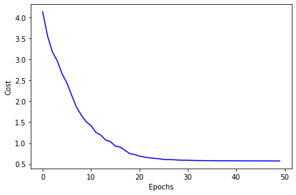

```python
# take the mean of each minibatch epoch
cost_avgs = [np.mean(x) for x in nn_cross.cost_]

plt.plot(range(len(cost_avgs)), cost_avgs, color='blue')
plt.ylabel('Cost')
plt.xlabel('Epochs')
plt.tight_layout()
plt.show()
```

```python
# val_score_ is the accuracy score on test data
nn_cross.val_score_[-1]
```

```
0.2515126512651265
```

We ran the two-layer perceptron on data with non-normalized and non-one-hot-encoded attributes (specification: cost function is cross-entropy, the activation function is sigmoid, mini-batch gradient calculation, weights update using momentum, Initialize weights Glorot and He normalization) for 50 epochs.

The plot of Cost vs. Epochs indicates that training converges after about 30 epochs.

The prediction accuracy of this model is 25.1%

### Train the the neural network with normalized continuous numeric attributes

```python
from sklearn.preprocessing import MinMaxScaler

normalized_columns = df_imputed.columns.tolist()[2:]
normalized_columns.remove('ChildPoverty')

values_to_normalized = df_imputed[normalized_columns].values

scaler = MinMaxScaler(feature_range = (0 , 1))

scaler.fit(values_to_normalized)
normalized_values = scaler.transform(values_to_normalized)

df_normalized =  copy.deepcopy(df_imputed)
df_normalized[normalized_columns] = normalized_values

df_normalized.head()
```

|  | State | County | TotalPop | Men | Women | Hispanic | White | Black | Native | Asian | ... | Walk | OtherTransp | WorkAtHome | MeanCommute | Employed | PrivateWork | PublicWork | SelfEmployed | FamilyWork | Unemployment |
| --- | --- | --- | --- | --- | --- | --- | --- | --- | --- | --- | --- | --- | --- | --- | --- | --- | --- | --- | --- | --- | --- |
| 0 | 32 | 1224 | 0.090622 | 0.091377 | 0.090026 | 0.086 | 0.766 | 0.023 | 0.000000 | 0.135667 | ... | 0.006435 | 0.020599 | 0.024155 | 0.408895 | 0.109455 | 0.717576 | 0.229244 | 0.090717 | 0.022422 | 0.119427 |
| 1 | 4 | 417 | 0.058271 | 0.057351 | 0.059305 | 0.050 | 0.794 | 0.002 | 0.005030 | 0.089716 | ... | 0.002574 | 0.076779 | 0.147343 | 0.395983 | 0.069075 | 0.756364 | 0.104089 | 0.246835 | 0.000000 | 0.087580 |
| 2 | 33 | 1828 | 0.081549 | 0.088462 | 0.074981 | 0.079 | 0.790 | 0.030 | 0.004024 | 0.056893 | ... | 0.047619 | 0.024345 | 0.100242 | 0.249641 | 0.096491 | 0.749091 | 0.175960 | 0.135021 | 0.000000 | 0.039809 |
| 3 | 49 | 1197 | 0.074477 | 0.076117 | 0.073025 | 0.040 | 0.948 | 0.007 | 0.005030 | 0.000000 | ... | 0.015444 | 0.024345 | 0.028986 | 0.357245 | 0.068142 | 0.732121 | 0.173482 | 0.170886 | 0.000000 | 0.183121 |
| 4 | 4 | 417 | 0.082297 | 0.081390 | 0.083316 | 0.071 | 0.738 | 0.014 | 0.000000 | 0.137856 | ... | 0.015444 | 0.039326 | 0.084541 | 0.436155 | 0.099741 | 0.716364 | 0.154895 | 0.219409 | 0.026906 | 0.084395 |

5 rows × 36 columns

```python
y_normalized = df_normalized['ChildPoverty']
df_tmp = copy.deepcopy(df_normalized)
del df_tmp['ChildPoverty']
X_normalized = df_tmp


X_train_normalized, X_test_normalized, y_train_normalized, y_test_normalized = train_test_split(X_normalized,y_normalized,test_size = 0.2,
                                                    stratify=y_normalized,
                                                    random_state=7324,
                                                    shuffle=True)

X_train_normalized = X_train_normalized.to_numpy()
X_test_normalized = X_test_normalized.to_numpy()
y_train_normalized = y_train_normalized.to_numpy()
y_test_normalized = y_test_normalized.to_numpy()
```

```python
vals = {'n_hidden':50,
         'C':1e-2, 'epochs':50, 'eta':0.01,
         'alpha':0.1, 'decrease_const':0.1, 'minibatches':len(X_train_normalized)/256,
         'shuffle':True,'random_state':1}


nn_cross_normalized = TLPBetterInitial(**vals)
nn_cross_normalized.fit(X_train_normalized, y_train_normalized, print_progress=1, XY_test=(X_test_normalized, y_test_normalized));
```

```
Epoch: 50/50
```

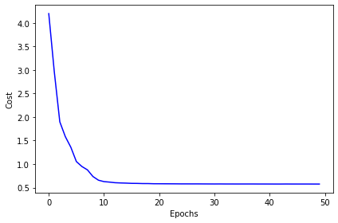

```python
# take the mean of each minibatch epoch
cost_avgs = [np.mean(x) for x in nn_cross_normalized.cost_]

plt.plot(range(len(cost_avgs)), cost_avgs, color='blue')
plt.ylabel('Cost')
plt.xlabel('Epochs')
plt.tight_layout()
plt.show()
```

```python
# yhat = nn_cross.predict(X_test)
# print('Validation acc:',accuracy_score(y_test,yhat))
nn_cross_normalized.val_score_[-1]
```

```
0.25254400440044006
```

We ran the two-layer perceptron on data with normalized continuous numeric attributes (specification: cost function is cross-entropy, the activation function is sigmoid, mini-batch gradient calculation, weights update using momentum, Initialize weights Glorot and He normalization) for 50 epochs.

The plot of Cost vs. Epochs indicates that training converges after about 15 epochs.

### Train the the neural network with normalized continuous attributes and one-hot encoded categorical attributes

```python
df_tmp = pd.get_dummies(df_normalized['State'],prefix='State')
df_normalized_encoded = pd.concat((df_normalized,df_tmp),axis=1)

df_tmp = pd.get_dummies(df_normalized['County'],prefix='County')
df_normalized_encoded = pd.concat((df_normalized,df_tmp),axis=1)

for col in ['State', 'County']:
    if col in df_normalized_encoded:
        del df_normalized_encoded[col]

df_normalized_encoded.head()
```

|  | TotalPop | Men | Women | Hispanic | White | Black | Native | Asian | Pacific | VotingAgeCitizen | ... | County_1944 | County_1945 | County_1946 | County_1947 | County_1948 | County_1949 | County_1950 | County_1951 | County_1952 | County_1953 |
| --- | --- | --- | --- | --- | --- | --- | --- | --- | --- | --- | --- | --- | --- | --- | --- | --- | --- | --- | --- | --- | --- |
| 0 | 0.090622 | 0.091377 | 0.090026 | 0.086 | 0.766 | 0.023 | 0.000000 | 0.135667 | 0.000000 | 0.110371 | ... | 0 | 0 | 0 | 0 | 0 | 0 | 0 | 0 | 0 | 0 |
| 1 | 0.058271 | 0.057351 | 0.059305 | 0.050 | 0.794 | 0.002 | 0.005030 | 0.089716 | 0.012517 | 0.073166 | ... | 0 | 0 | 0 | 0 | 0 | 0 | 0 | 0 | 0 | 0 |
| 2 | 0.081549 | 0.088462 | 0.074981 | 0.079 | 0.790 | 0.030 | 0.004024 | 0.056893 | 0.000000 | 0.095962 | ... | 0 | 0 | 0 | 0 | 0 | 0 | 0 | 0 | 0 | 0 |
| 3 | 0.074477 | 0.076117 | 0.073025 | 0.040 | 0.948 | 0.007 | 0.005030 | 0.000000 | 0.000000 | 0.100155 | ... | 0 | 0 | 0 | 0 | 0 | 0 | 0 | 0 | 0 | 0 |
| 4 | 0.082297 | 0.081390 | 0.083316 | 0.071 | 0.738 | 0.014 | 0.000000 | 0.137856 | 0.000000 | 0.097360 | ... | 0 | 0 | 0 | 0 | 0 | 0 | 0 | 0 | 0 | 0 |

5 rows × 1988 columns

```python
y = df_normalized_encoded['ChildPoverty']
df_tmp = copy.deepcopy(df_normalized_encoded)
del df_tmp['ChildPoverty']
X = df_tmp

X_train, X_test, y_train, y_test = train_test_split(X,y,test_size = 0.2,
                                                    stratify=y,
                                                    random_state=7324,
                                                    shuffle=True)
X_train = X_train.to_numpy()
X_test = X_test.to_numpy()
y_train = y_train.to_numpy()
y_test = y_test.to_numpy()
```

```python
vals = {'n_hidden':50,
         'C':1e-2, 'epochs':120, 'eta':0.01,
         'alpha':0.1, 'decrease_const':0.1, 'minibatches':len(X_train)/256,
         'shuffle':True,'random_state':7324}

nn_cross_normalized_encoded = TLPBetterInitial(**vals)
nn_cross_normalized_encoded.fit(X_train, y_train, print_progress=1, XY_test=(X_test, y_test));
```

```
Epoch: 120/120
```

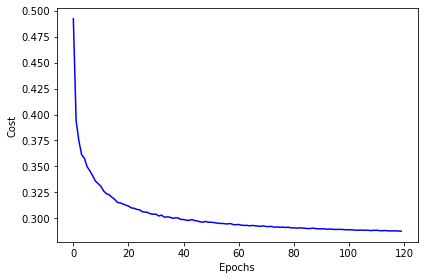

```python
# take the mean of each minibatch epoch
cost_avgs = [np.mean(x) for x in nn_cross_normalized_encoded.cost_]

plt.plot(range(len(cost_avgs)), cost_avgs, color='blue')
plt.ylabel('Cost')
plt.xlabel('Epochs')
plt.tight_layout()
plt.show()
```

```python
# yhat = nn_cross.predict(X_test)
# print('Validation acc:',accuracy_score(y_test,yhat))
print(nn_cross_normalized_encoded.val_score_[-1])
```

```
0.7132150715071507
```

We ran the two-layer perceptron on data with normalized continuous attributes and one-hot encoded categorical attributes (specification: cost function is cross-entropy, the activation function is sigmoid, mini-batch gradient calculation, weights update using momentum, Initialize weights Glorot and He normalization) for 120 epochs.

The plot of Cost vs. Epochs indicates that training converges after about 100 epochs.

The prediction accuracy of this model is 71.3%.

```python
from sklearn.metrics import confusion_matrix
from sklearn.metrics import plot_confusion_matrix

conf_mat = confusion_matrix(y_test, nn_cross_normalized_encoded.predict(X_test))
conf_mat
```

```
array([[2924,  544,   86,   50],
       [ 909, 2053,  607,   75],
       [  72,  775, 2199,  597],
       [  16,   26,  414, 3197]])
```

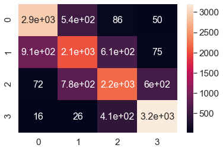

```python
import seaborn as sn
conf_mat_plot = pd.DataFrame(conf_mat, range(4), range(4))
# plt.figure(figsize=(10,7))
sn.set(font_scale=1.4) # for label size
sn.heatmap(conf_mat_plot, annot=True, annot_kws={"size": 16}) # font size
plt.show()
```

The above heatmap plots the confusion matrix from the above model. We can observe that the model has a better accuracy to predict class 3 and class 0 compared to class 1 and class 2.

```python
vals = {'n_hidden':50,
         'C':1e-2, 'epochs':250, 'eta':0.0001,
         'alpha':0.1, 'decrease_const':0.1, 'minibatches':len(X_train)/256,
         'shuffle':True,'random_state':7324}


rlu = TLPReLU(**vals)
rlu.fit(X_train, y_train, print_progress=1, XY_test=(X_test, y_test));
```

```
Epoch: 250/250
```

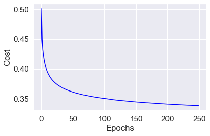

```python
# take the mean of each minibatch epoch
cost_avgs = [np.mean(x) for x in rlu.cost_]

plt.plot(range(len(cost_avgs)), cost_avgs, color='blue')
plt.ylabel('Cost')
plt.xlabel('Epochs')
plt.tight_layout()
plt.show()
```

```python
rlu.val_score_[-1]
```

```
0.675536303630363
```

We ran the two-layer perceptron on data with normalized continuous attributes and one-hot encoded categorical attributes (specification: cost function is cross-entropy, the activation function is rectified linear units (ReLu), mini-batch gradient calculation, weights update using momentum, Initialize weights using better initial weights for ReLu) for 250 epochs.

The plot of Cost vs. Epochs indicates that training converges after about 230 epochs.

The prediction accuracy of this model is 67.5%.

### Statistical comparison of models above using McNemar test

```python
# y_test is the true y values from the test data
# model1_pred  is the predicted y values from model 1
# model2_pred is the predicted y values from model 2

def create_contingency_MacNemar(y_test, model1_pred, model2_pred):

    correct1_correct2 = 0  # model 1 predict correctly, model 2 also predict correctly
    correct1_wrong2 = 0 # model 1 predict correctly, model 2 predict wrong
    wrong1_correct2 = 0
    wrong1_wrong2 = 0

    for i in range(len(y_test)):
        if model1_pred[i] == y_test[i] and model2_pred[i] == y_test[i]:
            correct1_correct2 +=1
        elif model1_pred[i] == y_test[i] and model2_pred[i] != y_test[i]:
            correct1_wrong2 +=1
        elif model1_pred[i] != y_test[i] and model2_pred[i] == y_test[i]:
            wrong1_correct2 +=1
        else:
            wrong1_wrong2 +=1
    return [[correct1_correct2, correct1_wrong2], [wrong1_correct2, wrong1_wrong2]]
```

```python
# https://machinelearningmastery.com/mcnemars-test-for-machine-learning/

# Example of calculating the mcnemar test
from statsmodels.stats.contingency_tables import mcnemar
# define contingency table

def cal_mcnemar(table):

    # calculate mcnemar test
    print(table)
    result = mcnemar(table, exact=True)
    # summarize the finding
    print('statistic=%.3f, p-value=%.3f' % (result.statistic, result.pvalue))
    # interpret the p-value
    alpha = 0.05
    if result.pvalue > alpha:
        print('Same proportions of errors (fail to reject H0)')
    else:
        print('Different proportions of errors (reject H0)')
```

#### McNemar test for raw data and normalized models (sigmoid)

```python
table = create_contingency_MacNemar(y_test, nn_cross_normalized.predict(X_test_normalized), nn_cross.predict(X_test_raw))
cal_mcnemar(table)
```

```
[[3, 3670], [3655, 7216]]
statistic=3655.000, p-value=0.870
Same proportions of errors (fail to reject H0)
```

We failed to reject the Null Hypothesis. Using significance level alpha = 0.05, we do not have sufficient evidence that these two models are different from each other. Therefore, in this test, we cannot conclude the normalized model is different from the raw data model.

#### McNemar test for raw data and normalized one-hot encoded models (sigmoid)

```python
table = create_contingency_MacNemar(y_test, nn_cross_normalized_encoded.predict(X_test), nn_cross.predict(X_test_raw))
cal_mcnemar(table)
```

```
[[2216, 8157], [1442, 2729]]
statistic=1442.000, p-value=0.000
Different proportions of errors (reject H0)
```

We reject the Null Hypothesis. Using significance level alpha = 0.05, we have sufficient evidence that these two models are different from each other. Therefore, the accuracy value can be used to determine which model has a better performance. In this test, the normalized-one-hot encoded model with accuracy close to 72 percent performed better than the model with raw data with 25 percent accuracy.

#### McNemar test for normalized data and normalized-one hot encoded models (sigmoid)

```python
table = create_contingency_MacNemar(y_test, nn_cross_normalized_encoded.predict(X_test), nn_cross_normalized.predict(X_test_normalized))
cal_mcnemar(table)
```

```
[[2102, 8271], [1571, 2600]]
statistic=1571.000, p-value=0.000
Different proportions of errors (reject H0)
```

We reject the Null Hypothesis. Using significance level alpha = 0.05, we have sufficient evidence that these two models are different from each other. Therefore, the accuracy value can be used to determine which model has a better performance. In this test, the normalized-one-hot encoded model with accuracy close to 72 percent performed better than the model with normalized data with 25 percent accuracy.

#### McNemar test for normalized-one hot encoded models (sigmoid vs ReLu)

```python
table = create_contingency_MacNemar(y_test, nn_cross_normalized_encoded.predict(X_test), rlu.predict(X_test))
cal_mcnemar(table)
```

```
[[9068, 1305], [757, 3414]]
statistic=757.000, p-value=0.000
Different proportions of errors (reject H0)
```

We reject the Null Hypothesis. Using significance level alpha = 0.05, we have sufficient evidence that these two models are different from each other. Therefore, the accuracy value can be used to determine which model has a better performance. In this test, the normalized-one-hot encoded model with accuracy close to 72 percent performed better than the ReLu model with 67 percent accuracy.

```python
# three-layer perceptron

import numpy as np
from scipy.special import expit
import pandas as pd
import sys
from sklearn.metrics import accuracy_score

# innermost layer has n1_hidden neurons
class ThreeLayerPerceptronBase(object):
    def __init__(self, n1_hidden=30, n2_hidden=20,
                 C=0.0, epochs=5, eta=0.001, random_state=7324): # set a small epoch for testing
        np.random.seed(random_state)
        self.n1_hidden = n1_hidden
        self.n2_hidden = n2_hidden
        self.l2_C = C
        self.epochs = epochs
        self.eta = eta

    @staticmethod
    def _encode_labels(y):
        """Encode labels into one-hot representation"""
        onehot = pd.get_dummies(y).values.T

        return onehot

    def _initialize_weights(self):
        """Initialize weights with small random numbers."""
        W1_num_elems = (self.n_features_ + 1)*self.n1_hidden
        W1 = np.random.uniform(-1.0, 1.0,size=W1_num_elems)
        W1 = W1.reshape(self.n1_hidden, self.n_features_ + 1) # reshape to be W1

        W2_num_elems = (self.n1_hidden + 1)*self.n2_hidden
        W2 = np.random.uniform(-1.0, 1.0,size=W2_num_elems)
        W2 = W2.reshape(self.n2_hidden, self.n1_hidden + 1)

        W3_num_elems = (self.n2_hidden + 1)*self.n_output_
        W3 = np.random.uniform(-1.0, 1.0, size=W3_num_elems)
        W3 = W3.reshape(self.n_output_, self.n2_hidden + 1)
        return W1, W2, W3

    @staticmethod
    def _sigmoid(z):
        """Use scipy.special.expit to avoid overflow"""
        # 1.0 / (1.0 + np.exp(-z))
        return expit(z)

    @staticmethod
    def _add_bias_unit(X, how='column'):
        """Add bias unit (column or row of 1s) to array at index 0"""
        if how == 'column':
            ones = np.ones((X.shape[0], 1))
            X_new = np.hstack((ones, X))
        elif how == 'row':
            ones = np.ones((1, X.shape[1]))
            X_new = np.vstack((ones, X))
        return X_new

    @staticmethod
    def _L2_reg(lambda_, W1, W2, W3):
        """Compute L2-regularization cost"""
        # only compute for non-bias terms
        return (lambda_/2.0) * np.sqrt(np.mean(W1[:, 1:] ** 2) + np.mean(W2[:, 1:] ** 2)+
                                       np.mean(W3[:, 1:] ** 2))

    def _cost(self,A4,Y_enc,W1,W2,W3):
        '''Get the objective function value'''
        cost = np.mean((Y_enc-A4)**2)
        L2_term = self._L2_reg(self.l2_C, W1, W2, W3)
        return cost + L2_term

    def _feedforward(self, X, W1, W2, W3):
        """Compute feedforward step
        """
        A1 = self._add_bias_unit(X, how='column')
        A1 = A1.T
        Z1 = W1 @ A1

        A2 = self._sigmoid(Z1)
        A2 = self._add_bias_unit(A2, how='row')
        Z2 = W2 @ A2

        A3 = self._sigmoid(Z2)
        A3 = self._add_bias_unit(A3, how='row')
        Z3 = W3 @ A3

        A4 = self._sigmoid(Z3)
        return A1, Z1, A2, Z2, A3, Z3, A4

    def _get_gradient(self, A1, A2, A3, A4, Z1, Z2, Z3, Y_enc, W1, W2, W3):
        """ Compute gradient step using backpropagation.
        """
        # vectorized backpropagation
        V3 = -2*(Y_enc-A4)*A4*(1-A4)  # last layer sensitivity
        V2 = A3*(1-A3)*(W3.T @ V3) # backpropogate the sensitivity
        V1 = A2*(1-A2)*(W2.T @ V2[1:, :])

        grad3 = V3 @ A3.T # no bias on final layer
        grad2 = V2[1:,:] @ A2.T
        grad1 = V1[1:,:] @ A1.T # dont back prop sensitivity of bias


        # regularize weights that are not bias terms
        grad1[:, 1:] += W1[:, 1:] * self.l2_C
        grad2[:, 1:] += W2[:, 1:] * self.l2_C
        grad3[:, 1:] += W3[:, 1:] * self.l2_C

        return grad1, grad2, grad3

    def predict(self, X):
        """Predict class labels"""
        _, _, _, _,_, _, A4 = self._feedforward(X, self.W1, self.W2, self.W3)
        y_pred = np.argmax(A4, axis=0)
        return y_pred
```

```python
class ThreeLPMiniBatch(ThreeLayerPerceptronBase):
    def __init__(self, alpha=0.0, decrease_const=0.0, shuffle=True,
                 minibatches=1, **kwds):
        # need to add to the original initializer
        self.alpha = alpha
        self.decrease_const = decrease_const
        self.shuffle = shuffle
        self.minibatches = minibatches
        # but keep other keywords
        super().__init__(**kwds)

    def fit(self, X, y, print_progress=False, XY_test=None):
        """ Learn weights from training data. With mini-batch"""
        X_data, y_data = X.copy(), y.copy()
        Y_enc = self._encode_labels(y)

        # init weights and setup matrice                                                                                                                                                                                                                                                                                                                                                                                                                                                                                                                                                                                                                                                                                                                                                                                            s
        self.n_features_ = X_data.shape[1]
        self.n_output_ = Y_enc.shape[0]
        self.W1, self.W2, self.W3 = self._initialize_weights()

        rho_W1_prev = np.zeros(self.W1.shape)
        rho_W2_prev = np.zeros(self.W2.shape)
        rho_W3_prev = np.zeros(self.W3.shape)

        self.cost_ = []
        self.score_ = []
        # get starting acc
        self.score_.append(accuracy_score(y_data,self.predict(X_data)))
        # keep track of validation, if given
        if XY_test is not None:
            X_test = XY_test[0].copy()
            y_test = XY_test[1].copy()
            self.val_score_ = []
            self.val_score_.append(accuracy_score(y_test,self.predict(X_test)))

        # keep track of gradients of each epoch
        self.grad_w1_ = np.zeros(self.epochs)
        self.grad_w2_ = np.zeros(self.epochs)
        self.grad_w3_ = np.zeros(self.epochs)

        for i in range(self.epochs):

            # adaptive learning rate
            # \frac{\eta}{1+\epsilon\cdot k}
            eta = self.eta / (1 + self.decrease_const*i)

            if print_progress>0 and (i+1)%print_progress==0:
                sys.stderr.write('\rEpoch: %d/%d' % (i+1, self.epochs))
                sys.stderr.flush()

            if self.shuffle:
                idx_shuffle = np.random.permutation(y_data.shape[0])
                X_data, Y_enc, y_data = X_data[idx_shuffle], Y_enc[:, idx_shuffle], y_data[idx_shuffle]

            mini = np.array_split(range(y_data.shape[0]), self.minibatches)
            mini_cost = []

            # keep track of gradients of each minibach in each epoch
            mini_grad1 = []
            mini_grad2 = []
            mini_grad3 = []

            for idx in mini:

                # feedforward
                A1, Z1, A2, Z2, A3, Z3, A4 = self._feedforward(X_data[idx],
                                                       self.W1,
                                                       self.W2, self.W3)

                cost = self._cost(A4,Y_enc[:, idx],self.W1,self.W2, self.W3)
                mini_cost.append(cost) # this appends cost of mini-batch only

                # compute gradient via backpropagation
                grad1, grad2, grad3 = self._get_gradient(A1=A1, A2=A2, A3=A3, A4=A4,
                                                  Z1=Z1, Z2=Z2, Z3=Z3,
                                                  Y_enc=Y_enc[:, idx],
                                                  W1=self.W1, W2=self.W2, W3=self.W3)
                # keep track of gradients of each minibach in each epoch
                mini_grad1.append(grad1)
                mini_grad2.append(grad2)
                mini_grad3.append(grad3)

                # momentum calculations
                rho_W1, rho_W2, rho_W3 = eta * grad1, eta * grad2, eta * grad3
                self.W1 -= (rho_W1 + (self.alpha * rho_W1_prev))
                self.W2 -= (rho_W2 + (self.alpha * rho_W2_prev))
                self.W3 -= (rho_W3 + (self.alpha * rho_W3_prev))
                rho_W1_prev, rho_W2_prev, rho_W3_prev = rho_W1, rho_W2, rho_W3


            # magnitude of gradients grad_w1_ and grad_w2_
            self.grad_w1_[i] = np.mean(np.abs((np.mean(mini_grad1[:]))))
            self.grad_w2_[i] = np.mean(np.abs((np.mean(mini_grad2[:]))))
            self.grad_w3_[i] = np.mean(np.abs((np.mean(mini_grad3[:]))))

            self.cost_.append(mini_cost)
            self.score_.append(accuracy_score(y_data,self.predict(X_data)))
            if XY_test is not None:
                self.val_score_.append(accuracy_score(y_test,self.predict(X_test)))

        return self

class ThreeLPMiniBatchCrossEntropy(ThreeLPMiniBatch):
    def _cost(self,A4,Y_enc,W1,W2,W3 ):
        '''Get the objective function value'''
        cost = -np.mean(np.nan_to_num((Y_enc*np.log(A4)+(1-Y_enc)*np.log(1-A4))))
        L2_term = self._L2_reg(self.l2_C, W1, W2, W3)
        return cost + L2_term

    def _get_gradient(self, A1, A2, A3, A4, Z1, Z2, Z3, Y_enc, W1, W2, W3):
        """ Compute gradient step using backpropagation.
        """
        # vectorized backpropagation
        V3 = (A4-Y_enc)  # last layer sensitivity # <- this is only line that changed
        V2 = A3*(1-A3)*(W3.T @ V3) # backpropogate the sensitivity
        V1 = A2*(1-A2)*(W2.T @ V2[1:, :])

        grad3 = V3 @ A3.T # no bias on final layer
        grad2 = V2[1:,:] @ A2.T
        grad1 = V1[1:,:] @ A1.T # dont back prop sensitivity of bias

        # regularize weights that are not bias terms

        grad1[:, 1:] += W1[:, 1:] * self.l2_C
        grad2[:, 1:] += W2[:, 1:] * self.l2_C
        grad3[:, 1:] += W3[:, 1:] * self.l2_C

        return grad1, grad2, grad3

class ThreeLPBetterInitial(ThreeLPMiniBatchCrossEntropy):
    def _initialize_weights(self):
        """Initialize weights Glorot and He normalization."""
        init_bound = 4*np.sqrt(6. / (self.n1_hidden + self.n_features_ + 1))
        W1 = np.random.uniform(-init_bound, init_bound,(self.n1_hidden, self.n_features_ + 1))
        W1[:,:1] = 0

        # reduce the final layer magnitude in order to balance the size of the gradients
        # between
        init_bound = 4*np.sqrt(6 / (self.n1_hidden + self.n2_hidden + 1))
        W2 = np.random.uniform(-init_bound, init_bound,(self.n2_hidden, self.n1_hidden + 1))
        W2[:,:1] = 0

        init_bound = 4*np.sqrt(6 / (self.n_output_ + self.n2_hidden + 1))
        W3 = np.random.uniform(-init_bound, init_bound,(self.n_output_, self.n2_hidden + 1))
        W3[:,:1] = 0

        return W1, W2, W3


class ThreeLPReLU(ThreeLPBetterInitial):
    def _initialize_weights(self):
        """Initialize weights Glorot and He normalization."""
        init_bound = np.sqrt(2)*np.sqrt(6. / (self.n1_hidden + self.n_features_ + 1))
        W1 = np.random.uniform(-init_bound, init_bound,(self.n1_hidden, self.n_features_ + 1))
        W1[:,:1] = 0

        # reduce the final layer magnitude in order to balance the size of the gradients
        # between
        init_bound = np.sqrt(2)*np.sqrt(6 / (self.n1_hidden + self.n2_hidden + 1))
        W2 = np.random.uniform(-init_bound, init_bound,(self.n2_hidden, self.n1_hidden + 1))
        W2[:,:1] = 0

        init_bound = 4*np.sqrt(6 / (self.n_output_ + self.n2_hidden + 1))
        W3 = np.random.uniform(-init_bound, init_bound,(self.n_output_, self.n2_hidden + 1))
        W3[:,:1] = 0

        return W1, W2, W3

    @staticmethod
    def _relu(Z):
        return np.maximum(0, Z.copy())

    def _feedforward(self, X, W1, W2, W3):
        """Compute feedforward step
        """
        # A1->W1->ReLu->A2->W2->Sigmoid
        A1 = self._add_bias_unit(X.T, how='row')
        Z1 = W1 @ A1

        A2 = self._relu(Z1)
        A2 = self._add_bias_unit(A2, how='row')
        Z2 = W2 @ A2

        A3 = self._relu(Z2)
        A3 = self._add_bias_unit(A3, how='row')
        Z3 = W3 @ A3

        A4 = self._sigmoid(Z3) # never use relu as last layer for classification (yuck!)
        return A1, Z1, A2, Z2, A3, Z3, A4

    def _get_gradient(self, A1, A2, A3, A4, Z1, Z2, Z3, Y_enc, W1, W2, W3):
        """ Compute gradient step using backpropagation.
        """
        # vectorized backpropagation
        V3 = (A4-Y_enc)
        # V3[Z2<=0] = 0 # could can change to be relu back prop on this layer too!

        Z2_with_bias = self._add_bias_unit(Z2,how='row')
        V2 = (W3.T @ V3)
        V2[Z2_with_bias<=0] = 0

        # old update: V1 = A2*(1-A2)*(W2.T @ V2)
        # the derivative of sigmoid was A2(1-A2), but now that is relu
        # so we change it to:
        Z1_with_bias = self._add_bias_unit(Z1,how='row')
        V1 = (W2.T @ V2[1:, :])
        V1[Z1_with_bias<=0] = 0


        grad3 = V3 @ A3.T # no bias on final layer
        grad2 = V2[1:,:] @ A2.T
        grad1 = V1[1:,:] @ A1.T # dont back prop sensitivity of bias

        # regularize weights that are not bias terms
        grad1[:, 1:] += (W1[:, 1:] * self.l2_C)
        grad2[:, 1:] += (W2[:, 1:] * self.l2_C)
        grad3[:, 1:] += (W3[:, 1:] * self.l2_C)

        return grad1, grad2, grad3
```

```python
vals = { 'n1_hidden': 50, 'n2_hidden':30,
         'C':1e-2, 'epochs':75, 'eta':0.01,
         'random_state':7324,
         'alpha':0.1, 'decrease_const':0.1, 'minibatches':len(X_train)/256,
         'shuffle':True}


nn__CrossEntropy_three_layer = ThreeLPBetterInitial(**vals)
nn__CrossEntropy_three_layer.fit(X_train, y_train, print_progress=1, XY_test=(X_test, y_test));
```

```
Epoch: 75/75
```

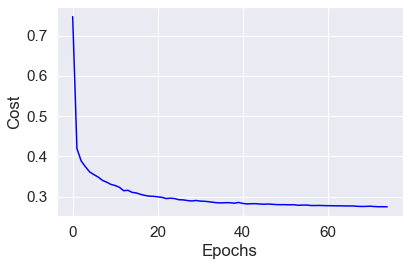

```python
# take the mean of each minibatch epoch
cost_avgs = [np.mean(x) for x in nn__CrossEntropy_three_layer.cost_]

plt.plot(range(len(cost_avgs)), cost_avgs, color='blue')
plt.ylabel('Cost')
plt.xlabel('Epochs')
plt.tight_layout()
plt.show()
```

```python
print(nn__CrossEntropy_three_layer.val_score_[-1])
```

```
0.7227035203520352
```

We ran the three-layer perceptron on data with normalized continuous attributes and one-hot encoded categorical attributes (specification: cost function is cross-entropy, the activation function is sigmoid, mini-batch gradient calculation, weights update using momentum, Initialize weights Glorot and He normalization) for 75 epochs.

The plot of Cost vs. Epochs indicates that training converges after about 60 epochs.

The prediction accuracy of this model is 72.3%.

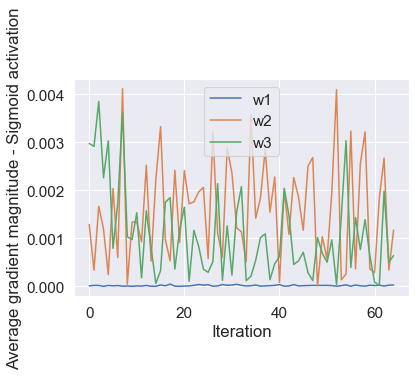

```python
ax = plt.subplot(1,1,1)
plt.plot(abs(nn__CrossEntropy_three_layer.grad_w1_[10:]), label='w1')
plt.plot(abs(nn__CrossEntropy_three_layer.grad_w2_[10:]), label='w2')
plt.plot(abs(nn__CrossEntropy_three_layer.grad_w3_[10:]), label='w3')
plt.legend()
plt.ylabel('Average gradient magnitude - Sigmoid activation')
plt.xlabel('Iteration')
plt.show()
```

The plot of "average gradient magnitude v.s. Iteration" shows that the average gradient magnitude at each iteration for the innermost layer is very close to 0. Thus, the weights of the innermost layer are random and probably not updated/trained.

```python
vals = {'n1_hidden': 30, 'n2_hidden':30,
         'C':1e-2, 'epochs':150, 'eta':0.0001,
         'alpha':0.1, 'decrease_const':0.1, 'minibatches':len(X_train)/256,
         'shuffle':True,'random_state':1}


nn__CrossEntropy_three_layer_Relu = ThreeLPReLU(**vals)
nn__CrossEntropy_three_layer_Relu.fit(X_train, y_train, print_progress=1, XY_test=(X_test, y_test));
```

```
Epoch: 150/150
```

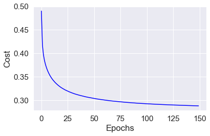

```python
# take the mean of each minibatch epoch
cost_avgs = [np.mean(x) for x in nn__CrossEntropy_three_layer_Relu.cost_]

plt.plot(range(len(cost_avgs)), cost_avgs, color='blue')
plt.ylabel('Cost')
plt.xlabel('Epochs')
plt.tight_layout()
plt.show()
```

```python
nn__CrossEntropy_three_layer_Relu.val_score_[-1]
```

```
0.7224972497249725
```

We ran the three-layer perceptron on data with normalized continuous attributes and one-hot encoded categorical attributes (specification: cost function is cross-entropy, the activation function is rectified linear units (ReLu), mini-batch gradient calculation, weights update using momentum, Initialize weights using better initial weights for ReLu) for 150 epochs.

The plot of Cost vs. Epochs indicates that training converges after about 140 epochs.

The prediction accuracy of this model is 72.2%.

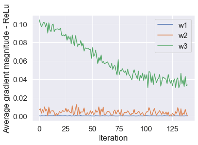

```python
ax = plt.subplot(1,1,1)
plt.plot(abs(nn__CrossEntropy_three_layer_Relu.grad_w1_[10:]), label='w1')
plt.plot(abs(nn__CrossEntropy_three_layer_Relu.grad_w2_[10:]), label='w2')
plt.plot(abs(nn__CrossEntropy_three_layer_Relu.grad_w3_[10:]), label='w3')
plt.legend()
plt.ylabel('Average gradient magnitude - ReLu')
plt.xlabel('Iteration')
plt.show()
```

The plot of "average gradient magnitude v.s. Iteration" shows that the average gradient magnitude at each iteration for the innermost layer is very close to 0. Thus, the weights of the innermost layer are random and probably not updated/trained. Also, the gradient magnitude of the outermost layer is significantly larger than other layers.

```python
# four-layer perceptron

# specify the number of hidden neurons
n1 = 30
n2 = 20
n3= 20

# innermost layer has n1_hidden neurons
class FourLayerPerceptronBase(object):
    def __init__(self, n1_hidden=n1, n2_hidden=n2, n3_hidden=n3,
                 C=0.0, epochs=5, eta=0.001, random_state=7324): # set a small epoch for testing
        np.random.seed(random_state)
        self.n1_hidden = n1_hidden
        self.n2_hidden = n2_hidden
        self.n3_hidden = n3_hidden
        self.l2_C = C
        self.epochs = epochs
        self.eta = eta

    @staticmethod
    def _encode_labels(y):
        """Encode labels into one-hot representation"""
        onehot = pd.get_dummies(y).values.T

        return onehot

    def _initialize_weights(self):
        """Initialize weights with small random numbers."""
        W1_num_elems = (self.n_features_ + 1)*self.n1_hidden
        W1 = np.random.uniform(-1.0, 1.0,size=W1_num_elems)
        W1 = W1.reshape(self.n1_hidden, self.n_features_ + 1) # reshape to be W1

        W2_num_elems = (self.n1_hidden + 1)*self.n2_hidden
        W2 = np.random.uniform(-1.0, 1.0,size=W2_num_elems)
        W2 = W2.reshape(self.n2_hidden, self.n1_hidden + 1)

        W3_num_elems = (self.n2_hidden + 1)*self.n3_hidden
        W3 = np.random.uniform(-1.0, 1.0,size=W3_num_elems)
        W3 = W3.reshape(self.n3_hidden, self.n2_hidden + 1)

        W4_num_elems = (self.n3_hidden + 1)*self.n_output_
        W4 = np.random.uniform(-1.0, 1.0, size=W4_num_elems)
        W4 = W4.reshape(self.n_output_, self.n3_hidden + 1)
        return W1, W2, W3, W4

    @staticmethod
    def _sigmoid(z):
        """Use scipy.special.expit to avoid overflow"""
        # 1.0 / (1.0 + np.exp(-z))
        return expit(z)

    @staticmethod
    def _add_bias_unit(X, how='column'):
        """Add bias unit (column or row of 1s) to array at index 0"""
        if how == 'column':
            ones = np.ones((X.shape[0], 1))
            X_new = np.hstack((ones, X))
        elif how == 'row':
            ones = np.ones((1, X.shape[1]))
            X_new = np.vstack((ones, X))
        return X_new

    @staticmethod
    def _L2_reg(lambda_, W1, W2, W3, W4):
        """Compute L2-regularization cost"""
        # only compute for non-bias terms
        return (lambda_/2.0) * np.sqrt(np.mean(W1[:, 1:] ** 2) + np.mean(W2[:, 1:] ** 2) +
                                       np.mean(W3[:, 1:] ** 2) + np.mean(W4[:, 1:] ** 2))

    def _cost(self,A4,Y_enc,W1,W2,W3,W4 ):
        '''Get the objective function value'''
        cost = np.mean((Y_enc-A5)**2)
        L2_term = self._L2_reg(self.l2_C, W1, W2, W3, W4)
        return cost + L2_term

    def _feedforward(self, X, W1, W2, W3, W4):
        """Compute feedforward step
        """
        A1 = self._add_bias_unit(X, how='column')
        A1 = A1.T
        Z1 = W1 @ A1

        A2 = self._sigmoid(Z1)
        A2 = self._add_bias_unit(A2, how='row')
        Z2 = W2 @ A2

        A3 = self._sigmoid(Z2)
        A3 = self._add_bias_unit(A3, how='row')
        Z3 = W3 @ A3

        A4 = self._sigmoid(Z3)
        A4 = self._add_bias_unit(A4, how='row')
        Z4 = W4 @ A4

        A5 = self._sigmoid(Z4)
        return A1, Z1, A2, Z2, A3, Z3, A4, Z4, A5

    def _get_gradient(self, A1, A2, A3, A4, A5, Z1, Z2, Z3,Z4, Y_enc, W1, W2, W3, W4):
        """ Compute gradient step using backpropagation.
        """
        # vectorized backpropagation
        V4 = -2*(Y_enc-A5)*A5*(1-A5)  # last layer sensitivity
        V3 = A4*(1-A4)*(W4.T @ V4)
        V2 = A3*(1-A3)*(W3.T @ V3[1:, :]) # backpropogate the sensitivity
        V1 = A2*(1-A2)*(W2.T @ V2[1:, :])


        grad4 = V4 @ A4.T # no bias on final layer
        grad3 = V3[1:,:] @ A3.T
        grad2 = V2[1:,:] @ A2.T
        grad1 = V1[1:,:] @ A1.T # dont back prop sensitivity of bias


        # regularize weights that are not bias terms

        grad1[:, 1:] += W1[:, 1:] * self.l2_C
        grad2[:, 1:] += W2[:, 1:] * self.l2_C
        grad3[:, 1:] += W3[:, 1:] * self.l2_C
        grad4[:, 1:] += W4[:, 1:] * self.l2_C

        return grad1, grad2, grad3, grad4

    def predict(self, X):
        """Predict class labels"""
        _, _, _, _,_, _,_, _, A5 = self._feedforward(X, self.W1, self.W2, self.W3, self.W4)
        y_pred = np.argmax(A5, axis=0)
        return y_pred
```

```python
class FourLPMiniBatch(FourLayerPerceptronBase):
    def __init__(self, alpha=0.0, decrease_const=0.0, shuffle=True,
                 minibatches=1, **kwds):
        # need to add to the original initializer
        self.alpha = alpha
        self.decrease_const = decrease_const
        self.shuffle = shuffle
        self.minibatches = minibatches
        # but keep other keywords
        super().__init__(**kwds)


    def fit(self, X, y, print_progress=False, XY_test=None):
        """ Learn weights from training data. With mini-batch"""
        X_data, y_data = X.copy(), y.copy()
        Y_enc = self._encode_labels(y)

        # init weights and setup matrices
        self.n_features_ = X_data.shape[1]
        self.n_output_ = Y_enc.shape[0]
        self.W1, self.W2, self.W3, self.W4 = self._initialize_weights()

        rho_W1_prev = np.zeros(self.W1.shape)
        rho_W2_prev = np.zeros(self.W2.shape)
        rho_W3_prev = np.zeros(self.W3.shape)
        rho_W4_prev = np.zeros(self.W4.shape)

        self.cost_ = []
        self.score_ = []
        # get starting acc
        self.score_.append(accuracy_score(y_data,self.predict(X_data)))
        # keep track of validation, if given
        if XY_test is not None:
            X_test = XY_test[0].copy()
            y_test = XY_test[1].copy()
            self.val_score_ = []
            self.val_score_.append(accuracy_score(y_test,self.predict(X_test)))

        # keep track of gradients of each epoch
        self.grad_w1_ = np.zeros(self.epochs)
        self.grad_w2_ = np.zeros(self.epochs)
        self.grad_w3_ = np.zeros(self.epochs)
        self.grad_w4_ = np.zeros(self.epochs)

        for i in range(self.epochs):

            # adaptive learning rate
            # \frac{\eta}{1+\epsilon\cdot k}
            eta = self.eta / (1 + self.decrease_const*i)

            if print_progress>0 and (i+1)%print_progress==0:
                sys.stderr.write('\rEpoch: %d/%d' % (i+1, self.epochs))
                sys.stderr.flush()

            if self.shuffle:
                idx_shuffle = np.random.permutation(y_data.shape[0])
                X_data, Y_enc, y_data = X_data[idx_shuffle], Y_enc[:, idx_shuffle], y_data[idx_shuffle]

            mini = np.array_split(range(y_data.shape[0]), self.minibatches)
            mini_cost = []

            # keep track of gradients of each minibach in each epoch
            mini_grad1 = []
            mini_grad2 = []
            mini_grad3 = []
            mini_grad4 = []

            for idx in mini:

                # feedforward
                A1, Z1, A2, Z2, A3, Z3, A4, Z4, A5 = self._feedforward(X_data[idx],
                                                       self.W1,
                                                       self.W2, self.W3, self.W4)

                cost = self._cost(A5, Y_enc[:, idx],self.W1,self.W2, self.W3,self.W4 )
                mini_cost.append(cost) # this appends cost of mini-batch only

                # compute gradient via backpropagation
                grad1, grad2, grad3, grad4 = self._get_gradient(A1=A1, A2=A2, A3=A3, A4=A4, A5=A5,
                                                  Z1=Z1, Z2=Z2, Z3=Z3, Z4=Z4,
                                                  Y_enc=Y_enc[:, idx],
                                                  W1=self.W1, W2=self.W2, W3=self.W3, W4=self.W4)

                # keep track of gradients of each minibach in each epoch
                mini_grad1.append(grad1)
                mini_grad2.append(grad2)
                mini_grad3.append(grad3)
                mini_grad4.append(grad4)

                # momentum calculations
                rho_W1, rho_W2, rho_W3, rho_W4 = eta * grad1, eta * grad2, eta * grad3, eta * grad4
                self.W1 -= (rho_W1 + (self.alpha * rho_W1_prev))
                self.W2 -= (rho_W2 + (self.alpha * rho_W2_prev))
                self.W3 -= (rho_W3 + (self.alpha * rho_W3_prev))
                self.W4 -= (rho_W4 + (self.alpha * rho_W4_prev))
                rho_W1_prev, rho_W2_prev, rho_W3_prev, rho_W4_prev = rho_W1, rho_W2, rho_W3, rho_W4

            # magnitude of gradients
            self.grad_w1_[i] = np.mean(np.abs((np.mean(mini_grad1[:]))))
            self.grad_w2_[i] = np.mean(np.abs((np.mean(mini_grad2[:]))))
            self.grad_w3_[i] = np.mean(np.abs((np.mean(mini_grad3[:]))))
            self.grad_w4_[i] = np.mean(np.abs((np.mean(mini_grad4[:]))))

            self.cost_.append(mini_cost)
            self.score_.append(accuracy_score(y_data,self.predict(X_data)))
            if XY_test is not None:
                self.val_score_.append(accuracy_score(y_test,self.predict(X_test)))

        return self

class FourLPMiniBatchCrossEntropy(FourLPMiniBatch):
    def _cost(self,A5,Y_enc,W1,W2,W3,W4 ):
        '''Get the objective function value'''
        cost = -np.mean(np.nan_to_num((Y_enc*np.log(A5)+(1-Y_enc)*np.log(1-A5))))
        L2_term = self._L2_reg(self.l2_C, W1, W2, W3, W4)
        return cost + L2_term

    def _get_gradient(self, A1, A2, A3, A4, A5, Z1, Z2, Z3,Z4, Y_enc, W1, W2, W3, W4):
        """ Compute gradient step using backpropagation.
        """
        # vectorized backpropagation
        V4 = (A5-Y_enc)  # last layer sensitivity
        V3 = A4*(1-A4)*(W4.T @ V4)
        V2 = A3*(1-A3)*(W3.T @ V3[1:, :]) # backpropogate the sensitivity
        V1 = A2*(1-A2)*(W2.T @ V2[1:, :])


        grad4 = V4 @ A4.T # no bias on final layer
        grad3 = V3[1:,:] @ A3.T
        grad2 = V2[1:,:] @ A2.T
        grad1 = V1[1:,:] @ A1.T # dont back prop sensitivity of bias


        # regularize weights that are not bias terms

        grad1[:, 1:] += W1[:, 1:] * self.l2_C
        grad2[:, 1:] += W2[:, 1:] * self.l2_C
        grad3[:, 1:] += W3[:, 1:] * self.l2_C
        grad4[:, 1:] += W4[:, 1:] * self.l2_C

        return grad1, grad2, grad3, grad4


class FourLPBetterInitial(FourLPMiniBatchCrossEntropy):
    def _initialize_weights(self):
        """Initialize weights Glorot and He normalization."""
        init_bound = 4*np.sqrt(6. / (self.n1_hidden + self.n_features_ + 1))
        W1 = np.random.uniform(-init_bound, init_bound,(self.n1_hidden, self.n_features_ + 1))
        W1[:,:1] = 0

        # reduce the final layer magnitude in order to balance the size of the gradients
        # between
        init_bound = 4*np.sqrt(6 / (self.n1_hidden + self.n2_hidden + 1))
        W2 = np.random.uniform(-init_bound, init_bound,(self.n2_hidden, self.n1_hidden + 1))
        W2[:,:1] = 0

        init_bound = 4*np.sqrt(6 / (self.n2_hidden + self.n3_hidden + 1))
        W3 = np.random.uniform(-init_bound, init_bound,(self.n3_hidden, self.n2_hidden + 1))
        W3[:,:1] = 0

        init_bound = 4*np.sqrt(6 / (self.n_output_ + self.n3_hidden + 1))
        W4 = np.random.uniform(-init_bound, init_bound,(self.n_output_, self.n3_hidden + 1))
        W4[:,:1] = 0

        return W1, W2, W3, W4


class FourLPReLU(FourLPBetterInitial):
    def _initialize_weights(self):
        """Initialize weights Glorot and He normalization."""
        init_bound = np.sqrt(2)*np.sqrt(6. / (self.n1_hidden + self.n_features_ + 1))
        W1 = np.random.uniform(-init_bound, init_bound,(self.n1_hidden, self.n_features_ + 1))
        W1[:,:1] = 0

        # reduce the final layer magnitude in order to balance the size of the gradients
        # between
        init_bound = np.sqrt(2)*np.sqrt(6 / (self.n1_hidden + self.n2_hidden + 1))
        W2 = np.random.uniform(-init_bound, init_bound,(self.n2_hidden, self.n1_hidden + 1))
        W2[:,:1] = 0

        init_bound = np.sqrt(2)*np.sqrt(6 / (self.n2_hidden + self.n3_hidden + 1))
        W3 = np.random.uniform(-init_bound, init_bound,(self.n3_hidden, self.n2_hidden + 1))
        W3[:,:1] = 0

        init_bound = 4*np.sqrt(6 / (self.n_output_ + self.n3_hidden + 1))
        W4 = np.random.uniform(-init_bound, init_bound,(self.n_output_, self.n3_hidden + 1))
        W4[:,:1] = 0

        return W1, W2, W3, W4

    @staticmethod
    def _relu(Z):
        return np.maximum(0, Z.copy())

    def _feedforward(self, X, W1, W2, W3, W4):
        """Compute feedforward step
        """
        # A1->W1->ReLu->A2->W2->Sigmoid
        A1 = self._add_bias_unit(X.T, how='row')
        Z1 = W1 @ A1

        A2 = self._relu(Z1)
        A2 = self._add_bias_unit(A2, how='row')
        Z2 = W2 @ A2

        A3 = self._relu(Z2)
        A3 = self._add_bias_unit(A3, how='row')
        Z3 = W3 @ A3

        A4 = self._relu(Z3)
        A4 = self._add_bias_unit(A4, how='row')
        Z4 = W4 @ A4

        A5 = self._sigmoid(Z4)
        return A1, Z1, A2, Z2, A3, Z3, A4, Z4, A5

    def _get_gradient(self, A1, A2, A3, A4, A5, Z1, Z2, Z3,Z4, Y_enc, W1, W2, W3, W4):
        """ Compute gradient step using backpropagation.
        """
        # vectorized backpropagation
        V4 = (A5-Y_enc)  # last layer sensitivity
        # V3[Z2<=0] = 0 # could can change to be relu back prop on this layer too!

        Z3_with_bias = self._add_bias_unit(Z3,how='row')
        V3 = (W4.T @ V4)
        V3[Z3_with_bias<=0] = 0

        Z2_with_bias = self._add_bias_unit(Z2,how='row')
        V2 = (W3.T @ V3[1:, :])
        V2[Z2_with_bias<=0] = 0

        # old update: V1 = A2*(1-A2)*(W2.T @ V2)
        # the derivative of sigmoid was A2(1-A2), but now that is relu
        # so we change it to:
        Z1_with_bias = self._add_bias_unit(Z1,how='row')
        V1 = (W2.T @ V2[1:, :])
        V1[Z1_with_bias<=0] = 0


        grad4 = V4 @ A4.T # no bias on final layer
        grad3 = V3[1:,:] @ A3.T
        grad2 = V2[1:,:] @ A2.T
        grad1 = V1[1:,:] @ A1.T # dont back prop sensitivity of bias

        # regularize weights that are not bias terms
        grad1[:, 1:] += (W1[:, 1:] * self.l2_C)
        grad2[:, 1:] += (W2[:, 1:] * self.l2_C)
        grad3[:, 1:] += (W3[:, 1:] * self.l2_C)
        grad4[:, 1:] += W4[:, 1:] * self.l2_C

        return grad1, grad2, grad3, grad4
```

```python
vals = { 'n1_hidden': 50, 'n2_hidden':30, 'n3_hidden':20,
         'C':1e-2, 'epochs': 100, 'eta':0.01,
         'random_state':7324,
         'alpha':0.1, 'decrease_const':0.1, 'minibatches':len(X_train)/256,
         'shuffle':True}


nn__CrossEntropy_Four_layer = FourLPBetterInitial(**vals)
nn__CrossEntropy_Four_layer.fit(X_train, y_train, print_progress=1, XY_test=(X_test, y_test));
```

```
Epoch: 100/100
```

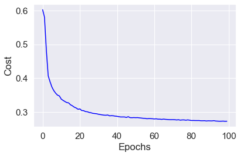

```python
# take the mean of each minibatch epoch
cost_avgs = [np.mean(x) for x in nn__CrossEntropy_Four_layer.cost_]

plt.plot(range(len(cost_avgs)), cost_avgs, color='blue')
plt.ylabel('Cost')
plt.xlabel('Epochs')
plt.tight_layout()
plt.show()
```

```python
print(nn__CrossEntropy_Four_layer.val_score_[-1])
```

```
0.7143151815181518
```

We ran the four-layer perceptron on data with normalized continuous attributes and one-hot encoded categorical attributes (specification: cost function is cross-entropy, the activation function is sigmoid, mini-batch gradient calculation, weights update using momentum, Initialize weights Glorot and He normalization) for 100 epochs.

The plot of Cost vs. Epochs indicates that training converges after about 80 epochs.

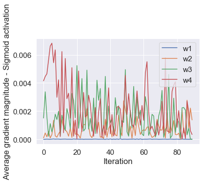

```python
ax = plt.subplot(1,1,1)
plt.plot(abs(nn__CrossEntropy_Four_layer.grad_w1_[10:]), label='w1')
plt.plot(abs(nn__CrossEntropy_Four_layer.grad_w2_[10:]), label='w2')
plt.plot(abs(nn__CrossEntropy_Four_layer.grad_w3_[10:]), label='w3')
plt.plot(abs(nn__CrossEntropy_Four_layer.grad_w4_[10:]), label='w4')
plt.legend()
plt.ylabel('Average gradient magnitude - Sigmoid activation')
plt.xlabel('Iteration')
plt.show()
```

The plot of "average gradient magnitude v.s. Iteration" shows that the average gradient magnitude at each iteration for the innermost layer is very close to 0. Thus, the weights of the innermost layer are random and probably not updated/trained. Also, the gradient magnitude of the outermost layer is higher than other layers but slightly less than the outer layer in the three-layer model on average.

```python
vals = {'n1_hidden': 30, 'n2_hidden':30,'n3_hidden':20,
         'C':1e-2, 'epochs':200, 'eta':0.0001,
         'alpha':0.1, 'decrease_const':0.1, 'minibatches':len(X_train)/256,
         'shuffle':True,'random_state':1}


nn__CrossEntropy_Four_layer_Relu = FourLPReLU(**vals)
nn__CrossEntropy_Four_layer_Relu.fit(X_train, y_train, print_progress=1, XY_test=(X_test, y_test));
```

```
Epoch: 200/200
```

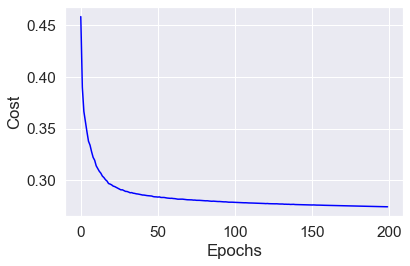

```python
# take the mean of each minibatch epoch
cost_avgs = [np.mean(x) for x in nn__CrossEntropy_Four_layer_Relu.cost_]

plt.plot(range(len(cost_avgs)), cost_avgs, color='blue')
plt.ylabel('Cost')
plt.xlabel('Epochs')
plt.tight_layout()
plt.show()
```

```python
nn__CrossEntropy_Four_layer_Relu.val_score_[-1]
```

```
0.7255225522552256
```

We ran the four-layer perceptron on data with normalized continuous attributes and one-hot encoded categorical attributes (specification: cost function is cross-entropy, the activation function is rectified linear units (ReLu), mini-batch gradient calculation, weights update using momentum, Initialize weights using better initial weights for ReLu) for 200 epochs.

The plot of Cost vs. Epochs indicates that training converges after about 175 epochs.

The prediction accuracy of this model is 72.6%.

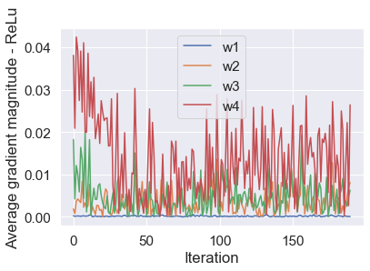

```python
ax = plt.subplot(1,1,1)
plt.plot(abs(nn__CrossEntropy_Four_layer_Relu.grad_w1_[10:]), label='w1')
plt.plot(abs(nn__CrossEntropy_Four_layer_Relu.grad_w2_[10:]), label='w2')
plt.plot(abs(nn__CrossEntropy_Four_layer_Relu.grad_w3_[10:]), label='w3')
plt.plot(abs(nn__CrossEntropy_Four_layer_Relu.grad_w4_[10:]), label='w4')
plt.legend()
plt.ylabel('Average gradient magnitude - ReLu')
plt.xlabel('Iteration')
plt.show()
```

The plot of "average gradient magnitude v.s. Iteration" shows that the average gradient magnitude at each iteration for the innermost layer is very close to 0. Thus, the weights of the innermost layer are random and probably not updated/trained. Also, the gradient magnitude of the outermost layer is higher than other layers. The gradient magnitude of each layer in ReLu is, on average, about ten times larger than those from sigmoid.

```python
# five-layer perceptron

# specify the number of hidden neurons
n1 = 30
n2 = 20
n3 = 20
n4 = 20

# innermost layer has n1_hidden neurons
class FiveLayerPerceptronBase(object):
    def __init__(self, n1_hidden=n1, n2_hidden=n2, n3_hidden=n3, n4_hidden=n4,
                 C=0.0, epochs=5, eta=0.001, random_state=7324): # set a small epoch for testing
        np.random.seed(random_state)
        self.n1_hidden = n1_hidden
        self.n2_hidden = n2_hidden
        self.n3_hidden = n3_hidden
        self.n4_hidden = n4_hidden
        self.l2_C = C
        self.epochs = epochs
        self.eta = eta

    @staticmethod
    def _encode_labels(y):
        """Encode labels into one-hot representation"""
        onehot = pd.get_dummies(y).values.T
        return onehot

    def _initialize_weights(self):
        """Initialize weights with small random numbers."""
        W1_num_elems = (self.n_features_ + 1)*self.n1_hidden
        W1 = np.random.uniform(-1.0, 1.0,size=W1_num_elems)
        W1 = W1.reshape(self.n1_hidden, self.n_features_ + 1) # reshape to be W1

        W2_num_elems = (self.n1_hidden + 1)*self.n2_hidden
        W2 = np.random.uniform(-1.0, 1.0,size=W2_num_elems)
        W2 = W2.reshape(self.n2_hidden, self.n1_hidden + 1)

        W3_num_elems = (self.n2_hidden + 1)*self.n3_hidden
        W3 = np.random.uniform(-1.0, 1.0,size=W3_num_elems)
        W3 = W3.reshape(self.n3_hidden, self.n2_hidden + 1)

        W4_num_elems = (self.n3_hidden + 1)*self.n4_hidden
        W4 = np.random.uniform(-1.0, 1.0,size=W4_num_elems)
        W4 = W4.reshape(self.n4_hidden, self.n3_hidden + 1)

        W5_num_elems = (self.n4_hidden + 1)*self.n_output_
        W5 = np.random.uniform(-1.0, 1.0, size=W5_num_elems)
        W5 = W5.reshape(self.n_output_, self.n4_hidden + 1)

        return W1, W2, W3, W4, W5

    @staticmethod
    def _sigmoid(z):
        """Use scipy.special.expit to avoid overflow"""
        # 1.0 / (1.0 + np.exp(-z))
        return expit(z)

    @staticmethod
    def _add_bias_unit(X, how='column'):
        """Add bias unit (column or row of 1s) to array at index 0"""
        if how == 'column':
            ones = np.ones((X.shape[0], 1))
            X_new = np.hstack((ones, X))
        elif how == 'row':
            ones = np.ones((1, X.shape[1]))
            X_new = np.vstack((ones, X))
        return X_new

    @staticmethod
    def _L2_reg(lambda_, W1, W2, W3, W4, W5):
        """Compute L2-regularization cost"""
        # only compute for non-bias terms
        return (lambda_/2.0) * np.sqrt(np.mean(W1[:, 1:] ** 2) + np.mean(W2[:, 1:] ** 2) +
                                       np.mean(W3[:, 1:] ** 2) + np.mean(W4[:, 1:] ** 2) +
                                       np.mean(W5[:, 1:] ** 2))

    def _cost(self,A6,Y_enc,W1,W2,W3,W4, W5 ):
        '''Get the objective function value'''
        cost = np.mean((Y_enc-A6)**2)
        L2_term = self._L2_reg(self.l2_C, W1, W2, W3, W4,W5 )
        return cost + L2_term

    def _feedforward(self, X, W1, W2, W3, W4, W5):
        """Compute feedforward step
        """
        A1 = self._add_bias_unit(X, how='column')
        A1 = A1.T
        Z1 = W1 @ A1

        A2 = self._sigmoid(Z1)
        A2 = self._add_bias_unit(A2, how='row')
        Z2 = W2 @ A2

        A3 = self._sigmoid(Z2)
        A3 = self._add_bias_unit(A3, how='row')
        Z3 = W3 @ A3

        A4 = self._sigmoid(Z3)
        A4 = self._add_bias_unit(A4, how='row')
        Z4 = W4 @ A4

        A5 = self._sigmoid(Z4)
        A5 = self._add_bias_unit(A5, how='row')
        Z5 = W5 @ A5

        A6 = self._sigmoid(Z5)
        return A1, Z1, A2, Z2, A3, Z3, A4, Z4, A5, Z5, A6

    def _get_gradient(self, A1, A2, A3, A4, A5, A6, Z1, Z2, Z3, Z4, Z5, Y_enc, W1, W2, W3, W4, W5):
        """ Compute gradient step using backpropagation.
        """
        # vectorized backpropagation
        V5 = -2*(Y_enc-A6)*A6*(1-A6)  # last layer sensitivity
        V4 = A5*(1-A5)*(W5.T @ V5)
        V3 = A4*(1-A4)*(W4.T @ V4[1:, :])
        V2 = A3*(1-A3)*(W3.T @ V3[1:, :]) # backpropogate the sensitivity
        V1 = A2*(1-A2)*(W2.T @ V2[1:, :])


        grad5 = V5 @ A5.T # no bias on final layer
        grad4 = V4[1:,:] @ A4.T
        grad3 = V3[1:,:] @ A3.T
        grad2 = V2[1:,:] @ A2.T
        grad1 = V1[1:,:] @ A1.T # dont back prop sensitivity of bias


        # regularize weights that are not bias terms

        grad1[:, 1:] += W1[:, 1:] * self.l2_C
        grad2[:, 1:] += W2[:, 1:] * self.l2_C
        grad3[:, 1:] += W3[:, 1:] * self.l2_C
        grad4[:, 1:] += W4[:, 1:] * self.l2_C
        grad5[:, 1:] += W5[:, 1:] * self.l2_C

        return grad1, grad2, grad3, grad4, grad5

    def predict(self, X):
        """Predict class labels"""
        _, _, _, _,_, _,_, _,_, _, A6 = self._feedforward(X, self.W1, self.W2, self.W3, self.W4, self.W5)
        y_pred = np.argmax(A6, axis=0)
        return y_pred
```

```python
class FiveLPMiniBatch(FiveLayerPerceptronBase):
    def __init__(self, alpha=0.0, decrease_const=0.0, shuffle=True,
                 minibatches=1, **kwds):
        # need to add to the original initializer
        self.alpha = alpha
        self.decrease_const = decrease_const
        self.shuffle = shuffle
        self.minibatches = minibatches
        super().__init__(**kwds)


    def fit(self, X, y, print_progress=False, XY_test=None):
        """ Learn weights from training data. With mini-batch"""
        X_data, y_data = X.copy(), y.copy()
        Y_enc = self._encode_labels(y)

        # init weights and setup matrices
        self.n_features_ = X_data.shape[1]
        self.n_output_ = Y_enc.shape[0]
        self.W1, self.W2, self.W3, self.W4, self.W5 = self._initialize_weights()

        rho_W1_prev = np.zeros(self.W1.shape)
        rho_W2_prev = np.zeros(self.W2.shape)
        rho_W3_prev = np.zeros(self.W3.shape)
        rho_W4_prev = np.zeros(self.W4.shape)
        rho_W5_prev = np.zeros(self.W5.shape)

        self.cost_ = []
        self.score_ = []
        # get starting acc
        self.score_.append(accuracy_score(y_data,self.predict(X_data)))
        # keep track of validation, if given
        if XY_test is not None:
            X_test = XY_test[0].copy()
            y_test = XY_test[1].copy()
            self.val_score_ = []
            self.val_score_.append(accuracy_score(y_test,self.predict(X_test)))

        # keep track of gradients of each epoch
        self.grad_w1_ = np.zeros(self.epochs)
        self.grad_w2_ = np.zeros(self.epochs)
        self.grad_w3_ = np.zeros(self.epochs)
        self.grad_w4_ = np.zeros(self.epochs)
        self.grad_w5_ = np.zeros(self.epochs)

        for i in range(self.epochs):

            # adaptive learning rate
            # \frac{\eta}{1+\epsilon\cdot k}
            eta = self.eta / (1 + self.decrease_const*i)

            if print_progress>0 and (i+1)%print_progress==0:
                sys.stderr.write('\rEpoch: %d/%d' % (i+1, self.epochs))
                sys.stderr.flush()

            if self.shuffle:
                idx_shuffle = np.random.permutation(y_data.shape[0])
                X_data, Y_enc, y_data = X_data[idx_shuffle], Y_enc[:, idx_shuffle], y_data[idx_shuffle]

            mini = np.array_split(range(y_data.shape[0]), self.minibatches)
            mini_cost = []

            # keep track of gradients of each minibach in each epoch
            mini_grad1 = []
            mini_grad2 = []
            mini_grad3 = []
            mini_grad4 = []
            mini_grad5 = []

            for idx in mini:

                # feedforward
                A1, Z1, A2, Z2, A3, Z3, A4, Z4, A5, Z5, A6 = self._feedforward(X_data[idx],
                                                       self.W1, self.W2, self.W3, self.W4, self.W5)

                cost = self._cost(A6, Y_enc[:, idx],self.W1,self.W2, self.W3,self.W4, self.W5 )
                mini_cost.append(cost) # this appends cost of mini-batch only

                # compute gradient via backpropagation
                grad1, grad2, grad3, grad4,grad5  = self._get_gradient(A1=A1, A2=A2, A3=A3, A4=A4, A5=A5,
                                                  A6=A6,Z1=Z1, Z2=Z2, Z3=Z3, Z4=Z4,Z5=Z5,
                                                  Y_enc=Y_enc[:, idx],
                                                  W1=self.W1, W2=self.W2, W3=self.W3,
                                                  W4=self.W4, W5=self.W5)
                # keep track of gradients of each minibach in each epoch
                mini_grad1.append(grad1)
                mini_grad2.append(grad2)
                mini_grad3.append(grad3)
                mini_grad4.append(grad4)
                mini_grad5.append(grad5)

                # momentum calculations
                rho_W1, rho_W2, rho_W3, rho_W4,rho_W5  = eta * grad1, eta * grad2, eta * grad3, eta * grad4, eta*grad5
                self.W1 -= (rho_W1 + (self.alpha * rho_W1_prev))
                self.W2 -= (rho_W2 + (self.alpha * rho_W2_prev))
                self.W3 -= (rho_W3 + (self.alpha * rho_W3_prev))
                self.W4 -= (rho_W4 + (self.alpha * rho_W4_prev))
                self.W5 -= (rho_W5 + (self.alpha * rho_W5_prev))
                rho_W1_prev, rho_W2_prev, rho_W3_prev, rho_W4_prev, rho_W5_prev = rho_W1, rho_W2, rho_W3, rho_W4, rho_W5

                # magnitude of gradients
            self.grad_w1_[i] = np.mean(np.abs((np.mean(mini_grad1[:]))))
            self.grad_w2_[i] = np.mean(np.abs((np.mean(mini_grad2[:]))))
            self.grad_w3_[i] = np.mean(np.abs((np.mean(mini_grad3[:]))))
            self.grad_w4_[i] = np.mean(np.abs((np.mean(mini_grad4[:]))))
            self.grad_w5_[i] = np.mean(np.abs((np.mean(mini_grad5[:]))))

            self.cost_.append(mini_cost)
            self.score_.append(accuracy_score(y_data,self.predict(X_data)))
            if XY_test is not None:
                self.val_score_.append(accuracy_score(y_test,self.predict(X_test)))

        return self

class FiveLPMiniBatchCrossEntropy(FiveLPMiniBatch):
    def _cost(self,A6,Y_enc,W1,W2,W3,W4,W5 ):
        '''Get the objective function value'''

        cost = -np.mean(np.nan_to_num((Y_enc*np.log(A6)+(1-Y_enc)*np.log(1-A6))))
        L2_term = self._L2_reg(self.l2_C, W1, W2, W3, W4, W5)
        return cost + L2_term

    def _get_gradient(self, A1, A2, A3, A4, A5, A6, Z1, Z2, Z3,Z4, Z5, Y_enc, W1, W2, W3, W4, W5):
        """ Compute gradient step using backpropagation.
        """
        # vectorized backpropagation
        V5 = (A6-Y_enc)   # last layer sensitivity
        V4 = A5*(1-A5)*(W5.T @ V5)
        V3 = A4*(1-A4)*(W4.T @ V4[1:, :])
        V2 = A3*(1-A3)*(W3.T @ V3[1:, :]) # backpropogate the sensitivity
        V1 = A2*(1-A2)*(W2.T @ V2[1:, :])


        grad5 = V5 @ A5.T # no bias on final layer
        grad4 = V4[1:,:] @ A4.T
        grad3 = V3[1:,:] @ A3.T
        grad2 = V2[1:,:] @ A2.T
        grad1 = V1[1:,:] @ A1.T # dont back prop sensitivity of bias


        # regularize weights that are not bias terms

        grad1[:, 1:] += W1[:, 1:] * self.l2_C
        grad2[:, 1:] += W2[:, 1:] * self.l2_C
        grad3[:, 1:] += W3[:, 1:] * self.l2_C
        grad4[:, 1:] += W4[:, 1:] * self.l2_C
        grad5[:, 1:] += W5[:, 1:] * self.l2_C

        return grad1, grad2, grad3, grad4, grad5


class FiveLPBetterInitial(FiveLPMiniBatchCrossEntropy):
    def _initialize_weights(self):
        """Initialize weights Glorot and He normalization."""
        init_bound = 4*np.sqrt(6. / (self.n1_hidden + self.n_features_ + 1))
        W1 = np.random.uniform(-init_bound, init_bound,(self.n1_hidden, self.n_features_ + 1))
        W1[:,:1] = 0

        # reduce the final layer magnitude in order to balance the size of the gradients
        # between
        init_bound = 4*np.sqrt(6 / (self.n1_hidden + self.n2_hidden + 1))
        W2 = np.random.uniform(-init_bound, init_bound,(self.n2_hidden, self.n1_hidden + 1))
        W2[:,:1] = 0

        init_bound = 4*np.sqrt(6 / (self.n2_hidden + self.n3_hidden + 1))
        W3 = np.random.uniform(-init_bound, init_bound,(self.n3_hidden, self.n2_hidden + 1))
        W3[:,:1] = 0

        init_bound = 4*np.sqrt(6 / (self.n3_hidden + self.n4_hidden + 1))
        W4 = np.random.uniform(-init_bound, init_bound,(self.n4_hidden, self.n3_hidden + 1))
        W4[:,:1] = 0

        init_bound = 4*np.sqrt(6 / (self.n_output_ + self.n4_hidden + 1))
        W5 = np.random.uniform(-init_bound, init_bound,(self.n_output_, self.n4_hidden + 1))
        W5[:,:1] = 0

        return W1, W2, W3, W4, W5


class FiveLPReLU(FiveLPBetterInitial):

    def _initialize_weights(self):
        """Initialize weights Glorot and He normalization."""
        init_bound = np.sqrt(2)*np.sqrt(6. / (self.n1_hidden + self.n_features_ + 1))
        W1 = np.random.uniform(-init_bound, init_bound,(self.n1_hidden, self.n_features_ + 1))
        W1[:,:1] = 0.0

        init_bound = np.sqrt(2)*np.sqrt(6 / (self.n1_hidden + self.n2_hidden + 1))
        W2 = np.random.uniform(-init_bound, init_bound,(self.n2_hidden, self.n1_hidden + 1))
        W2[:,:1] = 0.0

        init_bound = np.sqrt(2)*np.sqrt(6 / (self.n2_hidden + self.n3_hidden + 1))
        W3 = np.random.uniform(-init_bound, init_bound,(self.n3_hidden, self.n2_hidden + 1))
        W3[:,:1] = 0.0

        init_bound = np.sqrt(2)*np.sqrt(6 / (self.n3_hidden + self.n4_hidden + 1))
        W4 = np.random.uniform(-init_bound, init_bound,(self.n4_hidden, self.n3_hidden + 1))
        W4[:,:1] = 0.0

        init_bound = 4*np.sqrt(6 / (self.n_output_ + self.n4_hidden + 1))
        W5 = np.random.uniform(-init_bound, init_bound,(self.n_output_, self.n4_hidden + 1))
        W5[:,:1] = 0.0

        return W1, W2, W3, W4, W5

    @staticmethod
    def _relu(Z):
        return np.maximum(0, Z.copy())

    def _feedforward(self, X, W1, W2, W3, W4, W5):
        """Compute feedforward step
        """
        # A1->W1->ReLu->A2->W2->Sigmoid
        A1 = self._add_bias_unit(X.T, how='row')
        Z1 = W1 @ A1

        A2 = self._relu(Z1)
        A2 = self._add_bias_unit(A2, how='row')
        Z2 = W2 @ A2

        A3 = self._relu(Z2)
        A3 = self._add_bias_unit(A3, how='row')
        Z3 = W3 @ A3

        A4 = self._relu(Z3)
        A4 = self._add_bias_unit(A4, how='row')
        Z4 = W4 @ A4

        A5 = self._relu(Z4)
        A5 = self._add_bias_unit(A5, how='row')
        Z5 = W5 @ A5

        A6 = self._sigmoid(Z5)

        return A1, Z1, A2, Z2, A3, Z3, A4, Z4, A5, Z5, A6


    def _get_gradient(self, A1, A2, A3, A4, A5, A6, Z1, Z2, Z3, Z4, Z5, Y_enc, W1, W2, W3, W4, W5):
        """ Compute gradient step using backpropagation.
        """
        # vectorized backpropagation


        V5 = (A6-Y_enc)  # last layer sensitivity if use cross-entropy

        Z4_with_bias = self._add_bias_unit(Z4,how='row')
        V4 = (W5.T @ V5)
        V4[Z4_with_bias<=0] = 0

        Z3_with_bias = self._add_bias_unit(Z3,how='row')
        V3 = (W4.T @ V4[1:, :])
        V3[Z3_with_bias<=0] = 0

        Z2_with_bias = self._add_bias_unit(Z2,how='row')
        V2 = (W3.T @ V3[1:, :])
        V2[Z2_with_bias<=0] = 0

        # old update: V1 = A2*(1-A2)*(W2.T @ V2)
        # the derivative of sigmoid was A2(1-A2), but now that is relu
        # so we change it to:
        Z1_with_bias = self._add_bias_unit(Z1,how='row')
        V1 = (W2.T @ V2[1:, :])
        V1[Z1_with_bias<=0] = 0


        grad5 = V5 @ A5.T # no bias on final layer
        grad4 = V4[1:,:] @ A4.T
        grad3 = V3[1:,:] @ A3.T
        grad2 = V2[1:,:] @ A2.T
        grad1 = V1[1:,:] @ A1.T # dont back prop sensitivity of bias

        # regularize weights that are not bias terms
        grad1[:, 1:] += (W1[:, 1:] * self.l2_C)
        grad2[:, 1:] += (W2[:, 1:] * self.l2_C)
        grad3[:, 1:] += (W3[:, 1:] * self.l2_C)
        grad4[:, 1:] += (W4[:, 1:] * self.l2_C)
        grad5[:, 1:] += (W5[:, 1:] * self.l2_C)

        return grad1, grad2, grad3, grad4, grad5
```

```python
vals = { 'n1_hidden': 50, 'n2_hidden':40, 'n3_hidden':30, 'n4_hidden':20,
         'C':1e-2, 'epochs':150, 'eta':0.01,
         'random_state':7324,
         'alpha':0.1, 'decrease_const':0.1, 'minibatches':len(X_train)/256,
         'shuffle':True}


nn__CrossEntropy_Five_layer = FiveLPBetterInitial(**vals);
nn__CrossEntropy_Five_layer.fit(X_train, y_train, print_progress=1, XY_test=(X_test, y_test));
```

```
Epoch: 150/150
```

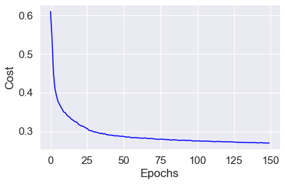

```python
# take the mean of each minibatch epoch
cost_avgs = [np.mean(x) for x in nn__CrossEntropy_Five_layer.cost_]

plt.plot(range(len(cost_avgs)), cost_avgs, color='blue')
plt.ylabel('Cost')
plt.xlabel('Epochs')
plt.tight_layout()
plt.show()
```

```python
print(nn__CrossEntropy_Five_layer.val_score_[-1])
```

```
0.7225660066006601
```

We ran the five-layer perceptron on data with normalized continuous attributes and one-hot encoded categorical attributes (specification: cost function is cross-entropy, the activation function is sigmoid, mini-batch gradient calculation, weights update using momentum, Initialize weights Glorot and He normalization) for 150 epochs.

The plot of Cost vs. Epochs indicates that training converges after about 120 epochs.

The prediction accuracy of this model is 72.3%.

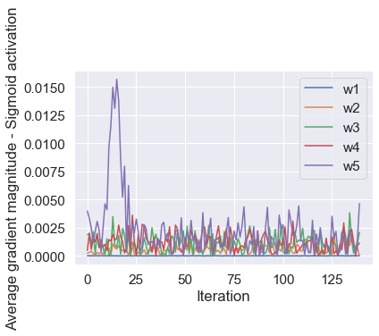

```python
ax = plt.subplot(1,1,1)
plt.plot(abs(nn__CrossEntropy_Five_layer.grad_w1_[10:]), label='w1')
plt.plot(abs(nn__CrossEntropy_Five_layer.grad_w2_[10:]), label='w2')
plt.plot(abs(nn__CrossEntropy_Five_layer.grad_w3_[10:]), label='w3')
plt.plot(abs(nn__CrossEntropy_Five_layer.grad_w4_[10:]), label='w4')
plt.plot(abs(nn__CrossEntropy_Five_layer.grad_w5_[10:]), label='w5')
plt.legend()
plt.ylabel('Average gradient magnitude - Sigmoid activation')
plt.xlabel('Iteration')
plt.show()
```

The plot of "average gradient magnitude v.s. Iteration" shows that the average gradient magnitude at each iteration for the innermost layer is very close to 0. Thus, the weights of the innermost layer are random and probably not updated/trained. The average gradient magnitudes of the layers are comparable except the innermost layer. However, the outermost layer shows a spike at the 20th epoch.

```python
vals = { 'n1_hidden': 50, 'n2_hidden':40, 'n3_hidden':30, 'n4_hidden':20,
         'C':1e-2, 'epochs':100, 'eta':0.0001,
         'random_state':7324,
         'alpha':0.1, 'decrease_const':0.1, 'minibatches':len(X_train)/256,
         'shuffle':True}


nn__CrossEntropy_Five_layer_Relu = FiveLPReLU(**vals);
nn__CrossEntropy_Five_layer_Relu.fit(X_train, y_train, print_progress=1, XY_test=(X_test, y_test));
```

```
Epoch: 100/100
```

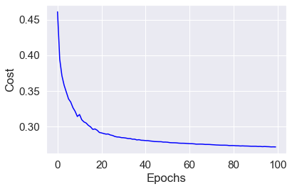

```python
# take the mean of each minibatch epoch
cost_avgs = [np.mean(x) for x in nn__CrossEntropy_Five_layer_Relu.cost_]

plt.plot(range(len(cost_avgs)), cost_avgs, color='blue')
plt.ylabel('Cost')
plt.xlabel('Epochs')
plt.tight_layout()
plt.show()
```

```python
nn__CrossEntropy_Five_layer_Relu.val_score_[-1]
```

```
0.7220159515951595
```

We ran the five-layer perceptron on data with normalized continuous attributes and one-hot encoded categorical attributes (specification: cost function is cross-entropy, the activation function is rectified linear units (ReLu), mini-batch gradient calculation, weights update using momentum, Initialize weights using better initial weights for ReLu) for 100 epochs.

The plot of Cost vs. Epochs indicates that training converges after about 90 epochs.

The prediction accuracy of this model is 72.2%.

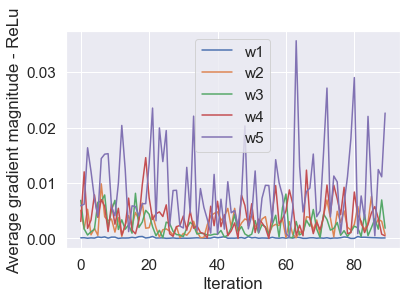

```python
ax = plt.subplot(1,1,1)
plt.plot(abs(nn__CrossEntropy_Five_layer_Relu.grad_w1_[10:]), label='w1')
plt.plot(abs(nn__CrossEntropy_Five_layer_Relu.grad_w2_[10:]), label='w2')
plt.plot(abs(nn__CrossEntropy_Five_layer_Relu.grad_w3_[10:]), label='w3')
plt.plot(abs(nn__CrossEntropy_Five_layer_Relu.grad_w4_[10:]), label='w4')
plt.plot(abs(nn__CrossEntropy_Five_layer_Relu.grad_w5_[10:]), label='w5')
plt.legend()
plt.ylabel('Average gradient magnitude - ReLu')
plt.xlabel('Iteration')
plt.show()
```

The plot of "average gradient magnitude v.s. Iteration" shows that the average gradient magnitude at each iteration for the innermost layer is very close to 0. Thus, the weights of the innermost layer are random and probably not updated/trained. Also, the average gradient magnitude of the outermost layer is significantly higher than other layers.

### Nesterov’s Accelerated Gradient (NAG) for adaptive learning

https://dominikschmidt.xyz/nesterov-momentum/

```python
class FiveLPReLU_netsterov(FiveLPReLU):

    def fit(self, X, y, print_progress=False, XY_test=None):
        """ Learn weights from training data. With mini-batch"""
        X_data, y_data = X.copy(), y.copy()
        Y_enc = self._encode_labels(y)

        # init weights and setup matrices
        self.n_features_ = X_data.shape[1]
        self.n_output_ = Y_enc.shape[0]
        self.W1, self.W2, self.W3, self.W4, self.W5 = self._initialize_weights()

        v1_prev = np.zeros(self.W1.shape)
        v2_prev = np.zeros(self.W2.shape)
        v3_prev = np.zeros(self.W3.shape)
        v4_prev = np.zeros(self.W4.shape)
        v5_prev = np.zeros(self.W5.shape)

        # keep track of gradients of each epoch
        self.grad_w1_ = np.zeros(self.epochs)
        self.grad_w2_ = np.zeros(self.epochs)
        self.grad_w3_ = np.zeros(self.epochs)
        self.grad_w4_ = np.zeros(self.epochs)
        self.grad_w5_ = np.zeros(self.epochs)

        self.cost_ = []
        self.score_ = []
        # get starting acc
        self.score_.append(accuracy_score(y_data,self.predict(X_data)))
        # keep track of validation, if given
        if XY_test is not None:
            X_test = XY_test[0].copy()
            y_test = XY_test[1].copy()
            self.val_score_ = []
            self.val_score_.append(accuracy_score(y_test,self.predict(X_test)))

        for i in range(self.epochs):

            # adaptive learning rate
            # \frac{\eta}{1+\epsilon\cdot k}
            eta = self.eta / (1 + self.decrease_const*i)

            if print_progress>0 and (i+1)%print_progress==0:
                sys.stderr.write('\rEpoch: %d/%d' % (i+1, self.epochs))
                sys.stderr.flush()

            if self.shuffle:
                idx_shuffle = np.random.permutation(y_data.shape[0])
                X_data, Y_enc, y_data = X_data[idx_shuffle], Y_enc[:, idx_shuffle], y_data[idx_shuffle]

            mini = np.array_split(range(y_data.shape[0]), self.minibatches)
            mini_cost = []

            # keep track of gradients of each minibach in each epoch
            mini_grad1 = []
            mini_grad2 = []
            mini_grad3 = []
            mini_grad4 = []
            mini_grad5 = []

            for idx in mini:

                # feedforward
                A1, Z1, A2, Z2, A3, Z3, A4, Z4, A5,Z5, A6 = self._feedforward(X_data[idx],
                                                       self.W1,
                                                       self.W2, self.W3, self.W4,self.W5)

                cost = self._cost(A6, Y_enc[:, idx],self.W1,self.W2, self.W3,self.W4, self.W5 )
                mini_cost.append(cost) # this appends cost of mini-batch only

                partial_w1 = self.alpha * v1_prev
                partial_w2 = self.alpha * v2_prev
                partial_w3 = self.alpha * v3_prev
                partial_w4 = self.alpha * v4_prev
                partial_w5 = self.alpha * v5_prev


                # compute gradient via backpropagation
                #https://dominikschmidt.xyz/nesterov-momentum/
                grad1, grad2, grad3, grad4,grad5  = self._get_gradient(A1=A1, A2=A2, A3=A3, A4=A4, A5=A5,
                                                  A6=A6,
                                                  Z1=Z1, Z2=Z2, Z3=Z3, Z4=Z4,Z5=Z5,
                                                  Y_enc=Y_enc[:, idx],
                                                  W1=self.W1 + partial_w1,
                                                  W2=self.W2 + partial_w2,
                                                  W3=self.W3 + partial_w3,
                                                  W4=self.W4 + partial_w4,
                                                  W5=self.W5 + partial_w5)

                # momentum calculations
                rho_W1, rho_W2, rho_W3, rho_W4,rho_W5  = eta * grad1, eta * grad2, eta * grad3, eta* grad4, eta * grad5

                # keep track of gradients of each minibach in each epoch
                mini_grad1.append(grad1)
                mini_grad2.append(grad2)
                mini_grad3.append(grad3)
                mini_grad4.append(grad4)
                mini_grad5.append(grad5)



                self.W1 += (partial_w1 - rho_W1)
                self.W2 += (partial_w2 - rho_W2)
                self.W3 += (partial_w3 - rho_W3)
                self.W4 += (partial_w4 - rho_W4)
                self.W5 += (partial_w5 - rho_W5)

                v1_prev, v2_prev, v3_prev, v4_prev, v5_prev =(partial_w1 - rho_W1), (partial_w2 - rho_W2), (partial_w3 - rho_W3), (partial_w4 - rho_W4), (partial_w5 - rho_W5)

            self.grad_w1_[i] = np.mean(np.abs((np.mean(mini_grad1[:]))))
            self.grad_w2_[i] = np.mean(np.abs((np.mean(mini_grad2[:]))))
            self.grad_w3_[i] = np.mean(np.abs((np.mean(mini_grad3[:]))))
            self.grad_w4_[i] = np.mean(np.abs((np.mean(mini_grad4[:]))))
            self.grad_w5_[i] = np.mean(np.abs((np.mean(mini_grad5[:]))))

            self.cost_.append(mini_cost)
            self.score_.append(accuracy_score(y_data,self.predict(X_data)))
            if XY_test is not None:
                self.val_score_.append(accuracy_score(y_test,self.predict(X_test)))

        return self
```

```python
%%time
vals = {'n1_hidden': 30, 'n2_hidden':30,'n3_hidden':30,'n4_hidden':30,
         'C':1e-2, 'epochs':200, 'eta':0.0001,
         'alpha':0.1, 'decrease_const':0.1, 'minibatches':len(X_train)/256,
         'shuffle':True,'random_state':1}


nn__CrossEntropy_Five_layer_Relu_netsterov = FiveLPReLU_netsterov(**vals)
nn__CrossEntropy_Five_layer_Relu_netsterov.fit(X_train, y_train, print_progress=1, XY_test=(X_test, y_test));
```

```
Epoch: 200/200
```

```
CPU times: user 28min 6s, sys: 2min 36s, total: 30min 42s
Wall time: 6min 47s
```

```
<__main__.FiveLPReLU_netsterov at 0x7f845c2997c0>
```

```python
nn__CrossEntropy_Five_layer_Relu_netsterov.val_score_[-1]
```

```
0.724491199119912
```

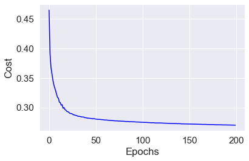

```python
# take the mean of each minibatch epoch
cost_avgs = [np.mean(x) for x in nn__CrossEntropy_Five_layer_Relu_netsterov.cost_]

plt.plot(range(len(cost_avgs)), cost_avgs, color='blue')
plt.ylabel('Cost')
plt.xlabel('Epochs')
plt.tight_layout()
plt.show()
```

We ran the five-layer perceptron on data with normalized continuous attributes and one-hot encoded categorical attributes (specification: cost function is cross-entropy, the activation function is rectified linear units (ReLu), mini-batch gradient calculation, weights update using NAG, Initialize weights using better initial weights for ReLu) for 200 epochs.

The plot of Cost vs. Epochs indicates that training converges after about 175 epochs.

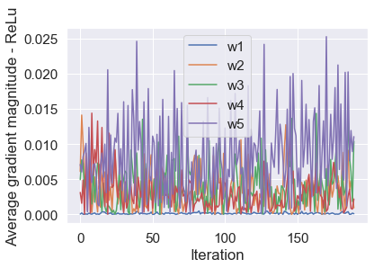

```python
ax = plt.subplot(1,1,1)
plt.plot(abs(nn__CrossEntropy_Five_layer_Relu_netsterov.grad_w1_[10:]), label='w1')
plt.plot(abs(nn__CrossEntropy_Five_layer_Relu_netsterov.grad_w2_[10:]), label='w2')
plt.plot(abs(nn__CrossEntropy_Five_layer_Relu_netsterov.grad_w3_[10:]), label='w3')
plt.plot(abs(nn__CrossEntropy_Five_layer_Relu_netsterov.grad_w4_[10:]), label='w4')
plt.plot(abs(nn__CrossEntropy_Five_layer_Relu_netsterov.grad_w5_[10:]), label='w5')
plt.legend()
plt.ylabel('Average gradient magnitude - ReLu')
plt.xlabel('Iteration')
plt.show()
```

The plot of "average gradient magnitude v.s. Iteration" shows that the average gradient magnitude at each iteration for the innermost layer is very close to 0. Thus, the weights of the innermost layer are random and probably not updated/trained. The outermost layer's average gradient magnitude is higher than other layers but slightly less than those from other five-layer implementations.

```python
table = create_contingency_MacNemar(y_test, nn__CrossEntropy_Five_layer_Relu_netsterov.predict(X_test), nn__CrossEntropy_Five_layer_Relu.predict(X_test))
cal_mcnemar(table)
```

```
[[10136, 401], [365, 3642]]
statistic=365.000, p-value=0.206
Same proportions of errors (fail to reject H0)
```

We failed to reject the Null Hypothesis. Using significance level alpha = 0.05, we do not have sufficient evidence that these two models are different from each other. Therefore, in this test, we cannot conclude the NAG -ReLu is different from the ReLu model.

### Exceptional work

#### Implement adaptive momentum (AdaM) in the five layer neural network and quantify the performance

ref: Adam https://ruder.io/optimizing-gradient-descent/index.html#adam

```python
class FiveLPReLU_Adam(FiveLPReLU):



    def fit(self, X, y, print_progress=False, XY_test=None):

         # keep track of gradients of each epoch
        self.grad_w1_ = np.zeros(self.epochs)
        self.grad_w2_ = np.zeros(self.epochs)
        self.grad_w3_ = np.zeros(self.epochs)
        self.grad_w4_ = np.zeros(self.epochs)
        self.grad_w5_ = np.zeros(self.epochs)

        """ Learn weights from training data. With mini-batch"""
        X_data, y_data = X.copy(), y.copy()
        Y_enc = self._encode_labels(y)

        # init weights and setup matrices
        self.n_features_ = X_data.shape[1]
        self.n_output_ = Y_enc.shape[0]
        self.W1, self.W2, self.W3, self.W4, self.W5 = self._initialize_weights()

        self.cost_ = []
        self.score_ = []
        # get starting acc
        self.score_.append(accuracy_score(y_data,self.predict(X_data)))
        # keep track of validation, if given
        if XY_test is not None:
            X_test = XY_test[0].copy()
            y_test = XY_test[1].copy()
            self.val_score_ = []
            self.val_score_.append(accuracy_score(y_test,self.predict(X_test)))

        beta1 = 0.9
        beta2 = 0.999
        # eta is defined as self.eta
        epsilon = 1e-8

        M1_prev = np.zeros(self.W1.shape)
        M2_prev = np.zeros(self.W2.shape)
        M3_prev = np.zeros(self.W3.shape)
        M4_prev = np.zeros(self.W4.shape)
        M5_prev = np.zeros(self.W5.shape)

        V1_prev = np.zeros(self.W1.shape)
        V2_prev = np.zeros(self.W2.shape)
        V3_prev = np.zeros(self.W3.shape)
        V4_prev = np.zeros(self.W4.shape)
        V5_prev = np.zeros(self.W5.shape)

        k = 0
        for i in range(self.epochs):

            k += 1
            # adaptive learning rate
            # \frac{\eta}{1+\epsilon\cdot k}

            if print_progress>0 and (i+1)%print_progress==0:
                sys.stderr.write('\rEpoch: %d/%d' % (i+1, self.epochs))
                sys.stderr.flush()

            if self.shuffle:
                idx_shuffle = np.random.permutation(y_data.shape[0])
                X_data, Y_enc, y_data = X_data[idx_shuffle], Y_enc[:, idx_shuffle], y_data[idx_shuffle]

            mini = np.array_split(range(y_data.shape[0]), self.minibatches)
            mini_cost = []

              # keep track of gradients of each minibach in each epoch
            mini_grad1 = []
            mini_grad2 = []
            mini_grad3 = []
            mini_grad4 = []
            mini_grad5 = []

            for idx in mini:

                # feedforward
                A1, Z1, A2, Z2, A3, Z3, A4, Z4, A5,Z5, A6 = self._feedforward(X_data[idx],
                                                       self.W1,
                                                       self.W2, self.W3, self.W4,self.W5)

                cost = self._cost(A6, Y_enc[:, idx],self.W1,self.W2, self.W3,self.W4, self.W5 )
                mini_cost.append(cost) # this appends cost of mini-batch only

                # compute gradient via backpropagation
                G1, G2, G3, G4, G5  = self._get_gradient(A1=A1, A2=A2, A3=A3, A4=A4, A5=A5,
                                                  A6=A6,
                                                  Z1=Z1, Z2=Z2, Z3=Z3, Z4=Z4,Z5=Z5,
                                                  Y_enc=Y_enc[:, idx],
                                                  W1=self.W1, W2=self.W2, W3=self.W3,
                                                  W4=self.W4, W5=self.W5)

                M1 = beta1*M1_prev + (1-beta1)*G1
                M2 = beta1*M2_prev + (1-beta1)*G2
                M3 = beta1*M3_prev + (1-beta1)*G3
                M4 = beta1*M4_prev + (1-beta1)*G4
                M5 = beta1*M5_prev + (1-beta1)*G5

                V1 = beta2*V1_prev + (1-beta2)*G1*G1
                V2 = beta2*V2_prev + (1-beta2)*G2*G2
                V3 = beta2*V3_prev + (1-beta2)*G3*G3
                V4 = beta2*V4_prev + (1-beta2)*G4*G4
                V5 = beta2*V5_prev + (1-beta2)*G5*G5




                M1_hat = M1/(1-(beta1)**(k))
                M2_hat = M2/(1-(beta1)**(k))
                M3_hat = M3/(1-(beta1)**(k))
                M4_hat = M4/(1-(beta1)**(k))
                M5_hat = M5/(1-(beta1)**(k))


                V1_hat = V1/(1-(beta2)**(k))
                V2_hat = V2/(1-(beta2)**(k))
                V3_hat = V3/(1-(beta2)**(k))
                V4_hat = V4/(1-(beta2)**(k))
                V5_hat = V5/(1-(beta2)**(k))




                self.W1 -= self.eta *(np.true_divide(M1_hat,(np.sqrt(V1_hat)+epsilon)))
                self.W2 -= self.eta *(np.true_divide(M2_hat,(np.sqrt(V2_hat)+epsilon)))
                self.W3 -= self.eta *(np.true_divide(M3_hat,(np.sqrt(V3_hat)+epsilon)))
                self.W4 -= self.eta *(np.true_divide(M4_hat,(np.sqrt(V4_hat)+epsilon)))
                self.W5 -= self.eta *(np.true_divide(M5_hat,(np.sqrt(V5_hat)+epsilon)))


                M1_prev, M2_prev, M3_prev, M4_prev, M5_prev = M1, M2, M3, M4, M5
                V1_prev, V2_prev, V3_prev, V4_prev, V5_prev = V1, V2, V3, V4, V5

                 # keep track of gradients of each minibach in each epoch
                mini_grad1.append(G1)
                mini_grad2.append(G2)
                mini_grad3.append(G3)
                mini_grad4.append(G4)
                mini_grad5.append(G5)




            self.grad_w1_[i] = np.mean(np.abs((np.mean(mini_grad1[:]))))
            self.grad_w2_[i] = np.mean(np.abs((np.mean(mini_grad2[:]))))
            self.grad_w3_[i] = np.mean(np.abs((np.mean(mini_grad3[:]))))
            self.grad_w4_[i] = np.mean(np.abs((np.mean(mini_grad4[:]))))
            self.grad_w5_[i] = np.mean(np.abs((np.mean(mini_grad5[:]))))

            self.cost_.append(mini_cost)
            self.score_.append(accuracy_score(y_data,self.predict(X_data)))
            if XY_test is not None:
                self.val_score_.append(accuracy_score(y_test,self.predict(X_test)))


        return self
```

```python
%%time
vals = {'n1_hidden': 30, 'n2_hidden':30,'n3_hidden':30,'n4_hidden':30,
         'C':1e-2, 'epochs':200, 'eta':0.0001,
         'alpha':0.1, 'decrease_const':0.1, 'minibatches':len(X_train)/256,
         'shuffle':True,'random_state':1}


nn__CrossEntropy_Five_layer_FiveLPReLU_Adam = FiveLPReLU_Adam(**vals)
nn__CrossEntropy_Five_layer_FiveLPReLU_Adam.fit(X_train, y_train, print_progress=1, XY_test=(X_test, y_test));
```

```
Epoch: 200/200
```

```
CPU times: user 29min 53s, sys: 2min 37s, total: 32min 31s
Wall time: 7min 6s
```

```
<__main__.FiveLPReLU_Adam at 0x7f846531d400>
```

```python
nn__CrossEntropy_Five_layer_FiveLPReLU_Adam.val_score_[-1]
```

```
0.7141776677667767
```

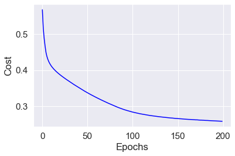

```python
# take the mean of each minibatch epoch
cost_avgs = [np.mean(x) for x in nn__CrossEntropy_Five_layer_FiveLPReLU_Adam.cost_]

plt.plot(range(len(cost_avgs)), cost_avgs, color='blue')
plt.ylabel('Cost')
plt.xlabel('Epochs')
plt.tight_layout()
plt.show()
```

We ran the five-layer perceptron on data with normalized continuous attributes and one-hot encoded categorical attributes (specification: cost function is cross-entropy, the activation function is rectified linear units (ReLu), mini-batch gradient calculation, weights update using AdaM, Initialize weights using better initial weights for ReLu) for 200 epochs.

The plot of Cost vs. Epochs indicates that training converges after about 160 epochs.

The prediction accuracy of this model is 71.4%.

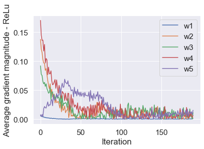

```python
ax = plt.subplot(1,1,1)
plt.plot(abs(nn__CrossEntropy_Five_layer_FiveLPReLU_Adam.grad_w1_[10:]), label='w1')
plt.plot(abs(nn__CrossEntropy_Five_layer_FiveLPReLU_Adam.grad_w2_[10:]), label='w2')
plt.plot(abs(nn__CrossEntropy_Five_layer_FiveLPReLU_Adam.grad_w3_[10:]), label='w3')
plt.plot(abs(nn__CrossEntropy_Five_layer_FiveLPReLU_Adam.grad_w4_[10:]), label='w4')
plt.plot(abs(nn__CrossEntropy_Five_layer_FiveLPReLU_Adam.grad_w5_[10:]), label='w5')
plt.legend()
plt.ylabel('Average gradient magnitude - ReLu')
plt.xlabel('Iteration')
plt.show()
```

The plot of "average gradient magnitude v.s. Iteration" shows the gradient magnitudes in different layers are close except the innermost layer. The average gradient magnitude at each iteration for the innermost layer is very close to 0. Thus, the weights of the innermost layer are random and probably not updated/trained.

```python
table = create_contingency_MacNemar(y_test, nn__CrossEntropy_Five_layer_Relu_netsterov.predict(X_test), nn__CrossEntropy_Five_layer_FiveLPReLU_Adam.predict(X_test))
cal_mcnemar(table)
```

```
[[9871, 666], [516, 3491]]
statistic=516.000, p-value=0.000
Different proportions of errors (reject H0)
```

We reject the Null Hypothesis. Using significance level alpha = 0.05, we have sufficient evidence that these two models are different from each other. Therefore, the accuracy value can be used to determine which model has a better performance. In this test, the NAG-ReLu model with accuracy close to 72 percent performed better than the Adam-ReLu model.

## Reference

Dataset https://www.kaggle.com/muonneutrino/us-census-demographic-data/data

ReLu https://www.cv-foundation.org/openaccess/content_iccv_2015/papers/He_Delving_Deep_into_ICCV_2015_paper.pdf